# DAT675 – Project

## Under What Biological and Statistical Conditions Does Multi-Task Learning Help or Hurt Toxicity Prediction?

**Team Members**  
Kevin Cheng (`kevinche@chalmers.se`)  
Qiuge Song (`qiuge@chalmers.se`)

## Project Overview

This project investigates when **multi-task learning (MTL)** improves toxicity prediction and when it instead leads to **negative transfer**, compared with **single-task learning (STL)**.

Using the **Tox21** dataset, we compare endpoint-level performance across classical machine learning baselines and graph neural network models. Our goal is not only to determine whether MTL performs better, but also to understand **under what biological and statistical conditions parameter sharing becomes helpful or harmful**.

More specifically, we study whether transfer behavior can be explained by:

- **biological grouping**, especially the difference between **Nuclear Receptor (NR)** and **Stress Response (SR)** tasks,
- **statistical properties** of the dataset, including **label coverage**, **class imbalance**, and **inter-task label correlation**,
- and the final **transfer outcome**, measured as improvement or degradation of **MTL relative to STL**.

## Revised Project Scope

To keep the project focused and feasible, we define the scope as follows:

1. **One dataset:** Tox21
2. **One main evaluation protocol:** scaffold split
3. **One main deep model family:** GCN
4. **Two classical baselines:** Logistic Regression and Random Forest
5. **One main comparison:** STL vs MTL at the endpoint level

## Working Definitions

- **Biological similarity:** endpoints belonging to the same Tox21 super-group (**NR** or **SR**), supported by label-correlation analysis
- **Negative transfer:** endpoint-level test **AUPRC** for **MTL** is lower than that for **STL**
- **Gradient analysis:** treated as an optional extension after stable STL and MTL baselines are established

## Summary of the Pipeline

Overall, the notebook follows the workflow below:

**Data profiling → Scaffold-based splitting → Feature engineering → Baseline modeling → Graph modeling → Repeated evaluation → Transfer analysis → Visualization → Final reporting**

This structure is designed to keep the project clear, reproducible, and easy to follow from start to finish.

## 1. Data Profiling and Preprocessing

This section prepares the dataset and ensures data quality before modeling. It focuses on understanding data characteristics and removing inconsistencies that could affect downstream results.

### 1.1 Imports and Global Settings

Set up the environment, random seeds, and global variables to ensure reproducibility and consistent configuration across the pipeline.

```python
# ============================================================
# 1.1 Imports and Global Settings
# ============================================================

import warnings
warnings.filterwarnings("ignore")

from pathlib import Path

import numpy as np
import pandas as pd
import matplotlib.pyplot as plt

from rdkit import Chem
from rdkit.Chem import MolStandardize
from rdkit.Chem.Scaffolds import MurckoScaffold
from sklearn.metrics import matthews_corrcoef

# ----------------------------
# Global settings
# ----------------------------
possible_paths = [
    Path("../data/raw/tox21.csv"),   # if notebook runs inside /notebooks
    Path("data/raw/tox21.csv"),      # if notebook runs from repo root
    Path("tox21.csv")                # fallback
]

DATA_PATH = None
for p in possible_paths:
    if p.exists():
        DATA_PATH = p.resolve()
        break

assert DATA_PATH is not None, "Data file not found in expected locations"

SMILES_COL = "smiles"

ALL_ENDPOINTS = [
    "NR-AR", "NR-AR-LBD", "NR-AhR", "NR-Aromatase", "NR-ER", "NR-ER-LBD",
    "NR-PPAR-gamma",
    "SR-ARE", "SR-ATAD5", "SR-HSE", "SR-MMP", "SR-p53"
]

NR_ENDPOINTS = [
    "NR-AR", "NR-AR-LBD", "NR-AhR", "NR-Aromatase", "NR-ER", "NR-ER-LBD",
    "NR-PPAR-gamma"
]

SR_ENDPOINTS = [
    "SR-ARE", "SR-ATAD5", "SR-HSE", "SR-MMP", "SR-p53"
]

SEED = 42
np.random.seed(SEED)

pd.set_option("display.max_columns", 100)
pd.set_option("display.width", 140)

print("Imports and global settings ready.")
print("Using data path:", DATA_PATH)
print("Number of endpoints:", len(ALL_ENDPOINTS))
```

```
Imports and global settings ready.
Using data path: C:\Users\lindy\Downloads\tox21.csv
Number of endpoints: 12
```

### 1.2 Dataset Loading and Initial Inspection

Load the Tox21 dataset and inspect its structure (size, columns, missing values) to understand the overall data distribution.

```python
# ============================================================
# 1.2 Dataset Loading and Initial Inspection
# ============================================================

assert DATA_PATH.exists(), f"Data file not found: {DATA_PATH}"

df_raw = pd.read_csv(DATA_PATH)
df = df_raw.copy()

assert SMILES_COL in df.columns, f"Missing required SMILES column: {SMILES_COL}"

missing_endpoints = [c for c in ALL_ENDPOINTS if c not in df.columns]
assert len(missing_endpoints) == 0, f"Missing endpoint columns: {missing_endpoints}"

initial_summary = pd.DataFrame({
    "Item": [
        "Number of molecules",
        "Number of columns",
        "SMILES missing",
        "Duplicate SMILES",
        "Number of endpoints"
    ],
    "Value": [
        len(df),
        df.shape[1],
        int(df[SMILES_COL].isna().sum()),
        int(df[SMILES_COL].duplicated().sum()),
        len(ALL_ENDPOINTS)
    ]
})

print(f"Raw dataset shape: {df.shape}")
display(initial_summary)
```

```
Raw dataset shape: (7831, 14)
```

|  | Item | Value |
| --- | --- | --- |
| 0 | Number of molecules | 7831 |
| 1 | Number of columns | 14 |
| 2 | SMILES missing | 0 |
| 3 | Duplicate SMILES | 0 |
| 4 | Number of endpoints | 12 |

### 1.3 Data Cleaning and SMILES Standardization

Standardize SMILES strings and remove invalid or duplicate molecules. This ensures that molecular representations are consistent and comparable across the dataset.

```python
# ============================================================
# 1.3 Data Cleaning and SMILES Standardization
# ============================================================
from rdkit import RDLogger
RDLogger.DisableLog('rdApp.*')
# RDKit standardization tools
normalizer = MolStandardize.rdMolStandardize.Normalizer()
reionizer = MolStandardize.rdMolStandardize.Reionizer()
uncharger = MolStandardize.rdMolStandardize.Uncharger()
fragment_chooser = MolStandardize.rdMolStandardize.LargestFragmentChooser()

def standardize_smiles(smiles):
    if pd.isna(smiles):
        return None

    mol = Chem.MolFromSmiles(smiles)
    if mol is None:
        return None

    try:
        mol = fragment_chooser.choose(mol)
        mol = normalizer.normalize(mol)
        mol = reionizer.reionize(mol)
        mol = uncharger.uncharge(mol)
        return Chem.MolToSmiles(mol, canonical=True)
    except Exception:
        return None

# ----------------------------
# Cleaning pipeline (silent)
# ----------------------------
n_before = len(df)

df = df.reset_index(drop=False).rename(columns={"index": "orig_idx"})
df["CanonicalSMILES"] = df[SMILES_COL].apply(standardize_smiles)

n_invalid = int(df["CanonicalSMILES"].isna().sum())

df = df.loc[df["CanonicalSMILES"].notna()].copy()

n_before_dedup = len(df)
df = df.drop_duplicates(subset="CanonicalSMILES").reset_index(drop=True)
n_removed_dup = n_before_dedup - len(df)

# ----------------------------
# Clean summary (ONLY output)
# ----------------------------
cleaning_summary = pd.DataFrame({
    "Metric": [
        "Raw molecules",
        "Invalid SMILES removed",
        "Duplicates removed",
        "Final dataset size"
    ],
    "Value": [
        n_before,
        n_invalid,
        n_removed_dup,
        len(df)
    ]
})

display(cleaning_summary)
```

|  | Metric | Value |
| --- | --- | --- |
| 0 | Raw molecules | 7831 |
| 1 | Invalid SMILES removed | 8 |
| 2 | Duplicates removed | 210 |
| 3 | Final dataset size | 7613 |

### 1.4 Missing Label Analysis

Analyze label sparsity across endpoints to understand data availability. This is critical because missing labels directly affect training and loss computation.

```python
# ============================================================
# 1.4 Missing Label Analysis
# ============================================================

missing_rows = []
n_total = len(df)

for endpoint in ALL_ENDPOINTS:
    n_missing = int(df[endpoint].isna().sum())
    n_observed = n_total - n_missing
    coverage = n_observed / n_total

    missing_rows.append({
        "Endpoint": endpoint,
        "Observed labels": n_observed,
        "Missing labels": n_missing,
        "Coverage": round(coverage, 3)
    })

missing_df = pd.DataFrame(missing_rows).sort_values(
    by=["Coverage", "Endpoint"], ascending=[True, True]
).reset_index(drop=True)

display(missing_df)

print("Mean label coverage:", round(missing_df["Coverage"].mean(), 3))
print("Lowest coverage endpoint:", missing_df.iloc[0]["Endpoint"])
print("Highest coverage endpoint:", missing_df.iloc[-1]["Endpoint"])
```

|  | Endpoint | Observed labels | Missing labels | Coverage |
| --- | --- | --- | --- | --- |
| 0 | NR-Aromatase | 5629 | 1984 | 0.739 |
| 1 | SR-MMP | 5636 | 1977 | 0.740 |
| 2 | SR-ARE | 5664 | 1949 | 0.744 |
| 3 | NR-ER | 6019 | 1594 | 0.791 |
| 4 | NR-PPAR-gamma | 6261 | 1352 | 0.822 |
| 5 | SR-HSE | 6284 | 1329 | 0.825 |
| 6 | NR-AhR | 6354 | 1259 | 0.835 |
| 7 | NR-AR-LBD | 6559 | 1054 | 0.862 |
| 8 | SR-p53 | 6582 | 1031 | 0.865 |
| 9 | NR-ER-LBD | 6759 | 854 | 0.888 |
| 10 | SR-ATAD5 | 6867 | 746 | 0.902 |
| 11 | NR-AR | 7050 | 563 | 0.926 |

```
Mean label coverage: 0.828
Lowest coverage endpoint: NR-Aromatase
Highest coverage endpoint: NR-AR
```

## Analysis of Label Coverage

The Tox21 dataset has relatively good label coverage overall, with a mean coverage of **0.828**. This means that most endpoints are labeled for a large proportion of molecules. However, the coverage is not completely uniform across tasks.

For example, **NR-Aromatase** has the lowest coverage (**0.739**), while **NR-AR** has the highest coverage (**0.926**). This difference shows that some endpoints provide less training information than others. As a result, endpoints with lower coverage may be harder to learn and may produce less stable evaluation results.

Overall, label sparsity is present, but it is not extreme. It is still an important factor to consider later when comparing STL and MTL performance.

### 1.5 Class Imbalance Analysis

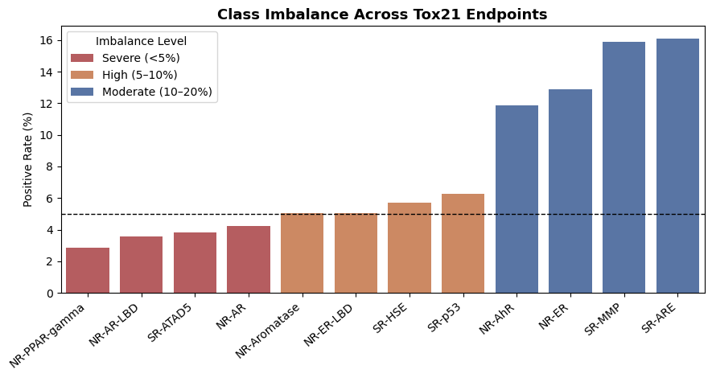

|  | Endpoint | Observed labels | Positive rate |
| --- | --- | --- | --- |
| 0 | NR-AR | 7050 | 0.043 |
| 1 | NR-AR-LBD | 6559 | 0.036 |
| 2 | NR-AhR | 6354 | 0.119 |
| 3 | NR-Aromatase | 5629 | 0.050 |
| 4 | NR-ER | 6019 | 0.129 |
| 5 | NR-ER-LBD | 6759 | 0.051 |
| 6 | NR-PPAR-gamma | 6261 | 0.029 |
| 7 | SR-ARE | 5664 | 0.161 |
| 8 | SR-ATAD5 | 6867 | 0.038 |
| 9 | SR-HSE | 6284 | 0.057 |
| 10 | SR-MMP | 5636 | 0.159 |
| 11 | SR-p53 | 6582 | 0.063 |

```python
# ============================================================
# 1.5 Class Imbalance Analysis
# ============================================================

import pandas as pd
import numpy as np
import seaborn as sns
import matplotlib.pyplot as plt

# ----------------------------
# Compute imbalance table
# ----------------------------
imbalance_rows = []

for endpoint in ALL_ENDPOINTS:
    y = df[endpoint]

    n_obs = y.notna().sum()
    n_pos = (y == 1).sum()

    pos_rate = n_pos / n_obs if n_obs > 0 else np.nan

    imbalance_rows.append({
        "Endpoint": endpoint,
        "Observed labels": n_obs,
        "Positive rate": pos_rate
    })

imbalance_df = pd.DataFrame(imbalance_rows)

# ----------------------------
# Convert to percentage
# ----------------------------
plot_df = imbalance_df.copy()
plot_df["Pos Rate (%)"] = plot_df["Positive rate"] * 100

# ----------------------------
# Categorize imbalance
# ----------------------------
def imbalance_category(p):
    if p < 5:
        return "Severe (<5%)"
    elif p < 10:
        return "High (5–10%)"
    elif p < 20:
        return "Moderate (10–20%)"
    else:
        return "Relatively balanced (>20%)"

plot_df["Imbalance"] = plot_df["Pos Rate (%)"].apply(imbalance_category)

# ----------------------------
# Plot
# ----------------------------
palette = {
    "Severe (<5%)": "#C44E52",
    "High (5–10%)": "#DD8452",
    "Moderate (10–20%)": "#4C72B0",
    "Relatively balanced (>20%)": "#55A868"
}

plt.figure(figsize=(9, 4.8))

sns.barplot(
    data=plot_df.sort_values("Pos Rate (%)"),
    x="Endpoint",
    y="Pos Rate (%)",
    hue="Imbalance",
    dodge=False,
    palette=palette
)

plt.axhline(5, linestyle="--", color="black", linewidth=1)

plt.xticks(rotation=40, ha="right")
plt.ylabel("Positive Rate (%)")
plt.xlabel("")
plt.title("Class Imbalance Across Tox21 Endpoints", fontsize=13, weight="bold")

plt.legend(title="Imbalance Level")
plt.tight_layout()
plt.show()

# ----------------------------
# Clean summary table
# ----------------------------
display(
    imbalance_df.style.format({
        "Positive rate": "{:.3f}"
    })
)
```

## Analysis of Class Imbalance

Although label coverage is fairly high, the dataset shows clear **class imbalance** across all endpoints. The positive class is rare in every task, and several endpoints fall below the **5% positive rate** threshold, which indicates severe imbalance.

This is important because imbalanced labels make toxicity prediction more difficult. A model can easily become biased toward the negative class, especially for endpoints with very few positive samples. For this reason, metrics such as **AUPRC** are more informative than simple accuracy.

The imbalance level also varies across endpoints. For example, **NR-PPAR-gamma** and **SR-ATAD5** are among the most imbalanced tasks, while **SR-ARE** and **SR-MMP** have relatively higher positive rates. This suggests that some endpoints may be easier to learn than others, which may later influence transfer behavior in multi-task learning.

### 1.6 Bemis–Murcko Scaffold Generation

Generate scaffolds to represent core molecular structures. This enables structure-based splitting, which better reflects real-world generalization.

```python
# ============================================================
# 1.6 Bemis–Murcko Scaffold Generation
# ============================================================

def get_scaffold(canonical_smiles):
    if pd.isna(canonical_smiles):
        return None

    mol = Chem.MolFromSmiles(canonical_smiles)
    if mol is None:
        return None

    try:
        scaffold = MurckoScaffold.MurckoScaffoldSmiles(mol=mol)
        if scaffold == "":
            return None
        return scaffold
    except Exception:
        return None

df["MurckoScaffold"] = df["CanonicalSMILES"].apply(get_scaffold)
df["EmptyScaffold"] = df["MurckoScaffold"].isna()

# For molecules without Murcko scaffold, use canonical SMILES as fallback scaffold
df["Scaffold"] = df["MurckoScaffold"].fillna(df["CanonicalSMILES"])

scaffold_summary = pd.DataFrame({
    "Metric": [
        "Total molecules",
        "Unique canonical SMILES",
        "Unique Murcko scaffolds (excluding empty)",
        "Empty Murcko scaffolds",
        "Final missing Scaffold values",
        "Unique final scaffold groups"
    ],
    "Value": [
        len(df),
        df["CanonicalSMILES"].nunique(),
        df["MurckoScaffold"].dropna().nunique(),
        int(df["EmptyScaffold"].sum()),
        int(df["Scaffold"].isna().sum()),
        df["Scaffold"].nunique()
    ]
})

display(scaffold_summary)
display(df[[SMILES_COL, "CanonicalSMILES", "MurckoScaffold", "EmptyScaffold", "Scaffold"]].head(5))
```

|  | Metric | Value |
| --- | --- | --- |
| 0 | Total molecules | 7613 |
| 1 | Unique canonical SMILES | 7613 |
| 2 | Unique Murcko scaffolds (excluding empty) | 2272 |
| 3 | Empty Murcko scaffolds | 1716 |
| 4 | Final missing Scaffold values | 0 |
| 5 | Unique final scaffold groups | 3988 |

|  | smiles | CanonicalSMILES | MurckoScaffold | EmptyScaffold | Scaffold |
| --- | --- | --- | --- | --- | --- |
| 0 | CCOc1ccc2nc(S(N)(=O)=O)sc2c1 | CCOc1ccc2nc(S(N)(=O)=O)sc2c1 | c1ccc2scnc2c1 | False | c1ccc2scnc2c1 |
| 1 | CCN1C(=O)NC(c2ccccc2)C1=O | CCN1C(=O)NC(c2ccccc2)C1=O | O=C1NC(=O)C(c2ccccc2)N1 | False | O=C1NC(=O)C(c2ccccc2)N1 |
| 2 | CC[C@]1(O)CC[C@H]2[C@@H]3CCC4=CCCC[C@@H]4[C@H]... | CC[C@]1(O)CC[C@H]2[C@@H]3CCC4=CCCC[C@@H]4[C@H]... | C1=C2CCC3C4CCCC4CCC3C2CCC1 | False | C1=C2CCC3C4CCCC4CCC3C2CCC1 |
| 3 | CCCN(CC)C(CC)C(=O)Nc1c(C)cccc1C | CCCN(CC)C(CC)C(=O)Nc1c(C)cccc1C | c1ccccc1 | False | c1ccccc1 |
| 4 | CC(O)(P(=O)(O)O)P(=O)(O)O | CC(O)(P(=O)(O)O)P(=O)(O)O | None | True | CC(O)(P(=O)(O)O)P(=O)(O)O |

### 1.7 Phi correlation heatmap

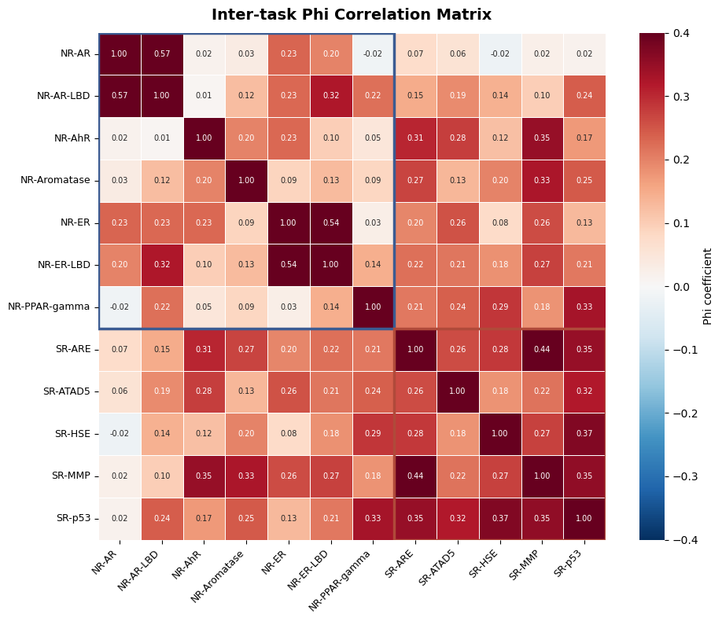

```python
# ============================================================
# Phi correlation heatmap
# ============================================================

import seaborn as sns

task_order = NR_ENDPOINTS + SR_ENDPOINTS
label_matrix = df[task_order].copy()

# -------------------------
# Compute Phi correlation
# -------------------------
n_tasks = len(task_order)
phi_matrix = np.full((n_tasks, n_tasks), np.nan)

for i in range(n_tasks):
    for j in range(n_tasks):
        mask = label_matrix[[task_order[i], task_order[j]]].notna().all(axis=1)

        if mask.sum() < 10:
            continue

        a = label_matrix.loc[mask, task_order[i]].values
        b = label_matrix.loc[mask, task_order[j]].values

        if a.std() == 0 or b.std() == 0:
            phi_matrix[i, j] = 0.0
        else:
            phi_matrix[i, j] = np.corrcoef(a, b)[0, 1]

phi_df = pd.DataFrame(phi_matrix, index=task_order, columns=task_order)

# -------------------------
# Plot heatmap
# -------------------------
fig, ax = plt.subplots(figsize=(10, 8))

sns.heatmap(
    phi_df,
    annot=True,
    fmt=".2f",
    cmap="RdBu_r",
    center=0,
    vmin=-0.4,
    vmax=0.4,
    square=True,
    linewidths=0.5,
    linecolor="white",
    cbar_kws={"label": "Phi coefficient"},
    annot_kws={"size": 7},
    ax=ax
)

# -------------------------
# Draw NR / SR blocks
# -------------------------
n_nr = len(NR_ENDPOINTS)
n_sr = len(SR_ENDPOINTS)

# NR block
ax.add_patch(
    plt.Rectangle((0, 0), n_nr, n_nr, fill=False, edgecolor="#3B5B92", lw=2.5)
)

# SR block
ax.add_patch(
    plt.Rectangle((n_nr, n_nr), n_sr, n_sr, fill=False, edgecolor="#B04A3A", lw=2.5)
)

# -------------------------
# Labels and title
# -------------------------
ax.set_title(
    "Inter-task Phi Correlation Matrix",
    fontsize=14,
    weight="bold",
    pad=12
)

ax.set_xticklabels(ax.get_xticklabels(), rotation=45, ha="right", fontsize=9)
ax.set_yticklabels(ax.get_yticklabels(), rotation=0, fontsize=9)

plt.tight_layout()
plt.show()
```

```python
# ============================================================
# Phi Summary Table (Clean + Robust)
# ============================================================

def summarize_phi(values):
    if len(values) == 0:
        return [np.nan] * 4 + [0]
    return [
        np.mean(values),
        np.median(values),
        np.min(values),
        np.max(values),
        len(values)
    ]

within_nr = []
within_sr = []
cross_nr_sr = []

for i, e1 in enumerate(ALL_ENDPOINTS):
    for j, e2 in enumerate(ALL_ENDPOINTS):
        if j <= i:
            continue

        idx1 = ALL_ENDPOINTS.index(e1)
        idx2 = ALL_ENDPOINTS.index(e2)
        val = phi_matrix[idx1, idx2]
        if pd.isna(val):
            continue

        if (e1 in NR_ENDPOINTS) and (e2 in NR_ENDPOINTS):
            within_nr.append(val)
        elif (e1 in SR_ENDPOINTS) and (e2 in SR_ENDPOINTS):
            within_sr.append(val)
        else:
            cross_nr_sr.append(val)

phi_summary = pd.DataFrame(
    [
        ["Within NR", *summarize_phi(within_nr)],
        ["Within SR", *summarize_phi(within_sr)],
        ["Cross NR-SR", *summarize_phi(cross_nr_sr)]
    ],
    columns=[
        "Group",
        "Mean Phi",
        "Median Phi",
        "Min Phi",
        "Max Phi",
        "Number of pairs"
    ]
)

# Sort groups for nicer reading (optional but clean)
phi_summary = phi_summary.set_index("Group")

display(
    phi_summary.style
    .format({
        "Mean Phi": "{:.3f}",
        "Median Phi": "{:.3f}",
        "Min Phi": "{:.3f}",
        "Max Phi": "{:.3f}"
    })
)
```

| Group | Mean Phi | Median Phi | Min Phi | Max Phi | Number of pairs |
| --- | --- | --- | --- | --- | --- |
| Within NR | 0.168 | 0.127 | -0.018 | 0.572 | 21 |
| Within SR | 0.305 | 0.302 | 0.181 | 0.439 | 10 |
| Cross NR-SR | 0.190 | 0.200 | -0.020 | 0.350 | 35 |

## Analysis of Inter-Task Phi Correlation

The Phi correlation matrix shows that task similarity is not uniform across Tox21 endpoints. Some endpoint pairs have relatively strong positive correlations, while others are only weakly related.

Within the **NR group**, a few pairs such as **NR-AR / NR-AR-LBD** and **NR-ER / NR-ER-LBD** show clearly stronger correlations. This makes sense because these endpoints are biologically related and may share similar response patterns. Within the **SR group**, correlations are also generally positive, with several moderate relationships among endpoints such as **SR-ARE**, **SR-MMP**, and **SR-p53**.

At the same time, cross-group correlations between **NR** and **SR** are not consistently low. Some NR–SR pairs still show moderate positive correlation. This suggests that biological grouping alone does not fully explain task similarity.

Overall, the Phi matrix suggests that multi-task learning may help when tasks share stronger label structure, but the benefit is likely to depend on the specific endpoint combination rather than only on the NR/SR grouping.

```python
# ============================================================
# Sanity Check Before Section 2
# ============================================================

required_cols = ["orig_idx", SMILES_COL, "CanonicalSMILES", "Scaffold"] + ALL_ENDPOINTS
missing_required = [c for c in required_cols if c not in df.columns]

assert len(missing_required) == 0, f"Missing required columns before Section 2: {missing_required}"

print("Section 1 completed successfully.")
print("Current dataframe shape:", df.shape)
print("Ready for scaffold-based splitting.")
```

```
Section 1 completed successfully.
Current dataframe shape: (7613, 19)
Ready for scaffold-based splitting.
```

## 2. Scaffold-Based Data Splitting

This section defines a realistic and robust evaluation protocol based on molecular structure rather than random sampling.

### 2.1 Grouping Molecules by Scaffold

This section defines a realistic and robust evaluation protocol based on molecular structure rather than random sampling.

```python
# ============================================================
# 2.1 Grouping Molecules by Scaffold
# ============================================================

from collections import defaultdict
import numpy as np
import pandas as pd
import matplotlib.pyplot as plt

assert "Scaffold" in df.columns, "Column 'Scaffold' not found. Please run Section 1.6 first."

# Reset index to make row tracking stable
df = df.reset_index(drop=True).copy()

# Group row indices by scaffold
scaffold_to_indices = defaultdict(list)
for idx, scaffold in enumerate(df["Scaffold"]):
    scaffold_to_indices[scaffold].append(idx)

# Sort scaffold groups by size (largest first)
scaffold_groups = sorted(scaffold_to_indices.values(), key=len, reverse=True)

scaffold_group_sizes = [len(g) for g in scaffold_groups]

grouping_summary = pd.DataFrame({
    "Metric": [
        "Total molecules",
        "Unique scaffold groups",
        "Largest scaffold group",
        "Median scaffold group size",
        "Singleton scaffold groups"
    ],
    "Value": [
        len(df),
        len(scaffold_groups),
        max(scaffold_group_sizes),
        int(np.median(scaffold_group_sizes)),
        sum(1 for x in scaffold_group_sizes if x == 1)
    ]
})

display(grouping_summary)
```

|  | Metric | Value |
| --- | --- | --- |
| 0 | Total molecules | 7613 |
| 1 | Unique scaffold groups | 3988 |
| 2 | Largest scaffold group | 1456 |
| 3 | Median scaffold group size | 1 |
| 4 | Singleton scaffold groups | 3438 |

### 2.2 Generating Repeated Scaffold Splits

Create multiple scaffold-based splits to improve robustness and reduce dependence on a single partition.

```python
# ============================================================
# 2.2 Generating Repeated Scaffold Splits
# ============================================================

def make_scaffold_split(df, scaffold_groups, seed=42, train_frac=0.8, val_frac=0.1, test_frac=0.1):
    """
    Assign scaffold groups to train / val / test without scaffold overlap.
    """
    assert abs(train_frac + val_frac + test_frac - 1.0) < 1e-8

    rng = np.random.RandomState(seed)
    groups = scaffold_groups.copy()
    rng.shuffle(groups)

    n_total = len(df)
    train_target = int(round(train_frac * n_total))
    val_target = int(round(val_frac * n_total))

    train_idx, val_idx, test_idx = [], [], []

    for group in groups:
        if len(train_idx) + len(group) <= train_target:
            train_idx.extend(group)
        elif len(val_idx) + len(group) <= val_target:
            val_idx.extend(group)
        else:
            test_idx.extend(group)

    # If val set ends up too small due to scaffold granularity, rebalance from test
    if len(val_idx) == 0 and len(test_idx) > 0:
        moved_group = test_idx[: max(1, len(test_idx) // 2)]
        val_idx.extend(moved_group)
        test_idx = test_idx[len(moved_group):]

    return {
        "train_idx": sorted(train_idx),
        "val_idx": sorted(val_idx),
        "test_idx": sorted(test_idx)
    }


N_SPLITS = 5
split_packs = []

for split_id in range(N_SPLITS):
    split_seed = SEED + split_id
    split = make_scaffold_split(
        df=df,
        scaffold_groups=scaffold_groups,
        seed=split_seed,
        train_frac=0.8,
        val_frac=0.1,
        test_frac=0.1
    )
    split["split_id"] = split_id
    split_packs.append(split)
```

### 2.3 Train / Validation / Test Partitioning

Divide scaffold groups into train, validation, and test sets (80/10/10) to ensure proper model development and evaluation.

```python
# ============================================================
# 2.3 Train / Validation / Test Partitioning
# ============================================================

def build_split_dataframes(df, split):
    train_df = df.loc[split["train_idx"]].copy()
    val_df   = df.loc[split["val_idx"]].copy()
    test_df  = df.loc[split["test_idx"]].copy()

    return {
        "train": train_df.reset_index(drop=True),
        "val": val_df.reset_index(drop=True),
        "test": test_df.reset_index(drop=True)
    }

# Build dataframe versions for all splits
split_data = [build_split_dataframes(df, split) for split in split_packs]

# Summary table across splits
split_summary_rows = []
for split, split_pack in zip(split_packs, split_data):
    n_train = len(split_pack["train"])
    n_val   = len(split_pack["val"])
    n_test  = len(split_pack["test"])
    n_total = n_train + n_val + n_test

    split_summary_rows.append({
        "Split": split["split_id"],
        "Train": n_train,
        "Validation": n_val,
        "Test": n_test,
        "Train frac": n_train / n_total,
        "Val frac": n_val / n_total,
        "Test frac": n_test / n_total
    })

split_summary_df = pd.DataFrame(split_summary_rows)

display(
    split_summary_df.style.format({
        "Train frac": "{:.3f}",
        "Val frac": "{:.3f}",
        "Test frac": "{:.3f}"
    })
)
```

|  | Split | Train | Validation | Test | Train frac | Val frac | Test frac |
| --- | --- | --- | --- | --- | --- | --- | --- |
| 0 | 0 | 6090 | 761 | 762 | 0.800 | 0.100 | 0.100 |
| 1 | 1 | 6090 | 761 | 762 | 0.800 | 0.100 | 0.100 |
| 2 | 2 | 6090 | 761 | 762 | 0.800 | 0.100 | 0.100 |
| 3 | 3 | 6090 | 761 | 762 | 0.800 | 0.100 | 0.100 |
| 4 | 4 | 6090 | 761 | 762 | 0.800 | 0.100 | 0.100 |

The scaffold-based splitting is very consistent across all five splits. In every case, the train, validation, and test sets follow the intended **80/10/10** ratio exactly.

This shows that scaffold grouping strongly controls the partitioning process. Because scaffolds are kept as whole groups, changing the random seed does not noticeably affect the final split sizes.

Overall, the splitting method is stable and reproducible. At the same time, the low variation across splits means that repeated evaluation may not provide very different testing scenarios.

### 2.4 Scaffold Leakage Check

Verify that no scaffold appears in more than one split. This ensures a strict evaluation of generalization to unseen chemical structures.

```python
# ============================================================
# 2.4 Scaffold Leakage Check
# ============================================================

# Rebuild split_data if needed
if "split_data" not in globals():
    def build_split_dataframes(df, split):
        return {
            "train": df.loc[split["train_idx"]].reset_index(drop=True),
            "val":   df.loc[split["val_idx"]].reset_index(drop=True),
            "test":  df.loc[split["test_idx"]].reset_index(drop=True)
        }
    split_data = [build_split_dataframes(df, split) for split in split_packs]

has_leakage = False

for split, split_pack in zip(split_packs, split_data):
    train_scaffolds = set(split_pack["train"]["Scaffold"])
    val_scaffolds   = set(split_pack["val"]["Scaffold"])
    test_scaffolds  = set(split_pack["test"]["Scaffold"])

    if (
        len(train_scaffolds & val_scaffolds) > 0
        or len(train_scaffolds & test_scaffolds) > 0
        or len(val_scaffolds & test_scaffolds) > 0
    ):
        has_leakage = True
        break

if has_leakage:
    print("Scaffold leakage detected between data partitions.")
else:
    print("No scaffold leakage was detected: train, validation, and test sets are fully scaffold-disjoint in all splits.")
```

```
No scaffold leakage was detected: train, validation, and test sets are fully scaffold-disjoint in all splits.
```

No scaffold leakage was detected in any split. This confirms that the train, validation, and test sets are fully scaffold-disjoint, which makes the evaluation more realistic and prevents information leakage between partitions.

### 2.5 Label Distribution Across Splits

Check that label distributions remain comparable across splits, avoiding unintended bias between train and test sets.

```
label_dist_df not found → rebuilding...
```

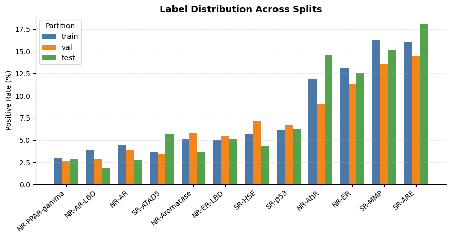

```python
# ============================================================
# Label Distribution Plot (Safe Version)
# ============================================================

import matplotlib.pyplot as plt
import numpy as np

# ---- Safety check ----
if "label_dist_df" not in globals():
    print("label_dist_df not found → rebuilding...")

    def summarize_labels(split_pack, endpoints):
        rows = []
        for part_name in ["train", "val", "test"]:
            part_df = split_pack[part_name]

            for endpoint in endpoints:
                y = part_df[endpoint].dropna()
                n_obs = len(y)
                n_pos = int((y == 1).sum())
                pos_rate = n_pos / n_obs if n_obs > 0 else np.nan

                rows.append({
                    "Partition": part_name,
                    "Endpoint": endpoint,
                    "Observed labels": n_obs,
                    "Positive rate": pos_rate
                })
        return pd.DataFrame(rows)

    main_split_pack = split_data[0]
    label_dist_df = summarize_labels(main_split_pack, ALL_ENDPOINTS)

# ---- Plot ----
plot_df = label_dist_df.copy()
plot_df["Positive rate (%)"] = plot_df["Positive rate"] * 100

partition_order = ["train", "val", "test"]

endpoint_order = (
    plot_df.groupby("Endpoint")["Positive rate (%)"]
    .mean()
    .sort_values()
    .index
)

fig, ax = plt.subplots(figsize=(9, 4.8))

x = np.arange(len(endpoint_order))
width = 0.25

colors = {
    "train": "#4C78A8",
    "val": "#F58518",
    "test": "#54A24B"
}

for i, part in enumerate(partition_order):
    sub = (
        plot_df[plot_df["Partition"] == part]
        .set_index("Endpoint")
        .loc[endpoint_order]
    )

    ax.bar(
        x + (i - 1) * width,
        sub["Positive rate (%)"],
        width=width,
        label=part,
        color=colors[part]
    )

ax.set_xticks(x)
ax.set_xticklabels(endpoint_order, rotation=40, ha="right")
ax.set_ylabel("Positive Rate (%)")
ax.set_title("Label Distribution Across Splits", fontsize=13, weight="bold")

ax.spines["top"].set_visible(False)
ax.spines["right"].set_visible(False)
ax.grid(axis="y", linestyle="--", alpha=0.3)

ax.legend(title="Partition")

plt.tight_layout()
plt.show()
```

```python
# ============================================================
# Clean Label Distribution Summary Table
# ============================================================

table_df = (
    label_dist_df
    .groupby(["Partition", "Endpoint"], as_index=False)
    .agg({
        "Observed labels": "mean",
        "Positive rate": "mean"
    })
)


pivot_df = table_df.pivot(
    index="Endpoint",
    columns="Partition",
    values="Positive rate"
)


pivot_df = pivot_df * 100


pivot_df = pivot_df.loc[endpoint_order]

display(
    pivot_df.style
    .format("{:.1f}")
    .set_caption("Positive Rate (%) Across Data Splits")
    .background_gradient(cmap="Blues")
)
```

Positive Rate (%) Across Data Splits

| Partition Endpoint | test | train | val |
| --- | --- | --- | --- |
| NR-PPAR-gamma | 2.8 | 2.9 | 2.7 |
| NR-AR-LBD | 1.9 | 3.9 | 2.9 |
| NR-AR | 2.8 | 4.5 | 3.8 |
| SR-ATAD5 | 5.7 | 3.6 | 3.4 |
| NR-Aromatase | 3.6 | 5.1 | 5.8 |
| NR-ER-LBD | 5.2 | 5.0 | 5.5 |
| SR-HSE | 4.3 | 5.7 | 7.2 |
| SR-p53 | 6.3 | 6.2 | 6.7 |
| NR-AhR | 14.6 | 11.9 | 9.0 |
| NR-ER | 12.5 | 13.1 | 11.4 |
| SR-MMP | 15.2 | 16.3 | 13.5 |
| SR-ARE | 18.1 | 16.0 | 14.5 |

```python
# ============================================================
# Final sanity check for Section 2
# ============================================================

main_split_id = 0  # use first split as default

print("Section 2 completed successfully.")
print(f"Number of scaffold splits generated: {len(split_data)}")
print(f"Main reporting split: {main_split_id}")
```

```
Section 2 completed successfully.
Number of scaffold splits generated: 5
Main reporting split: 0
```

### 3. Feature Engineering

This section converts molecular data into representations suitable for machine learning models.

### 3.1 Morgan Fingerprint Generation

This section converts molecular data into representations suitable for machine learning models.

```python
# ============================================================
# 3.1 Morgan Fingerprint Generation
# ============================================================

import numpy as np
import pandas as pd

from rdkit import Chem, DataStructs
from rdkit.Chem import AllChem

FP_RADIUS = 2
FP_NBITS = 2048

def smiles_to_morgan_fp(smiles, radius=FP_RADIUS, n_bits=FP_NBITS):
    """
    Convert a SMILES string to a Morgan fingerprint numpy array.
    Returns a zero vector if parsing fails.
    """
    arr = np.zeros((n_bits,), dtype=np.float32)

    if pd.isna(smiles):
        return arr

    mol = Chem.MolFromSmiles(smiles)
    if mol is None:
        return arr

    fp = AllChem.GetMorganFingerprintAsBitVect(mol, radius, nBits=n_bits)
    DataStructs.ConvertToNumpyArray(fp, arr)
    return arr

# Use canonical SMILES if available
fp_source_col = "CanonicalSMILES" if "CanonicalSMILES" in df.columns else SMILES_COL

df["MorganFP"] = df[fp_source_col].apply(smiles_to_morgan_fp)

fp_summary = pd.DataFrame({
    "Metric": [
        "Fingerprint type",
        "Radius",
        "Number of bits",
        "Number of molecules"
    ],
    "Value": [
        "Morgan / ECFP",
        FP_RADIUS,
        FP_NBITS,
        len(df)
    ]
})

display(fp_summary)
```

|  | Metric | Value |
| --- | --- | --- |
| 0 | Fingerprint type | Morgan / ECFP |
| 1 | Radius | 2 |
| 2 | Number of bits | 2048 |
| 3 | Number of molecules | 7613 |

### 3.2 Molecular Graph Construction in PyG Format

Convert molecules into graph structures for GNN models, preserving atom connectivity and topology.

```python
# ============================================================
# 3.2 Molecular Graph Construction in PyG Format
# ============================================================

try:
    import torch
    from torch_geometric.data import Data
    TORCH_AVAILABLE = True
    print("PyTorch and PyG imported successfully.")
except Exception as e:
    TORCH_AVAILABLE = False
    print("PyTorch / PyG import failed. Graph construction is skipped for now.")
    print("Error:", e)
import torch
from torch_geometric.data import Data

# Allowable feature sets
ATOM_SYMBOLS = [
    "B", "C", "N", "O", "F", "Si", "P", "S", "Cl", "Br", "I", "Unknown"
]
ATOM_DEGREES = [0, 1, 2, 3, 4, 5]
ATOM_FORMAL_CHARGES = [-2, -1, 0, 1, 2]
ATOM_HYBRIDIZATIONS = [
    Chem.rdchem.HybridizationType.SP,
    Chem.rdchem.HybridizationType.SP2,
    Chem.rdchem.HybridizationType.SP3,
    Chem.rdchem.HybridizationType.SP3D,
    Chem.rdchem.HybridizationType.SP3D2
]
ATOM_NUMHS = [0, 1, 2, 3, 4]
BOND_TYPES = [
    Chem.rdchem.BondType.SINGLE,
    Chem.rdchem.BondType.DOUBLE,
    Chem.rdchem.BondType.TRIPLE,
    Chem.rdchem.BondType.AROMATIC
]
```

```
PyTorch and PyG imported successfully.
```

### Atom and Bond Feature Encoding

Define node and edge features to represent chemical properties, enabling the GNN to learn meaningful molecular representations.

```python
# ============================================================
# 3.3 Atom and Bond Feature Encoding
# ============================================================

def one_hot_with_unknown(value, choices):
    """
    One-hot encode a value with the last position reserved as 'unknown'
    if the value is not found in choices.
    """
    encoding = [0] * (len(choices) + 1)
    if value in choices:
        encoding[choices.index(value)] = 1
    else:
        encoding[-1] = 1
    return encoding

def one_hot(value, choices):
    encoding = [0] * len(choices)
    if value in choices:
        encoding[choices.index(value)] = 1
    return encoding

def encode_atom(atom):
    """
    Atom feature vector.
    """
    symbol = atom.GetSymbol()
    if symbol not in ATOM_SYMBOLS[:-1]:
        symbol = "Unknown"

    features = []
    features += one_hot(symbol, ATOM_SYMBOLS)
    features += one_hot(atom.GetDegree(), ATOM_DEGREES)
    features += one_hot(atom.GetFormalCharge(), ATOM_FORMAL_CHARGES)
    features += one_hot(atom.GetHybridization(), ATOM_HYBRIDIZATIONS)
    features += one_hot(atom.GetTotalNumHs(), ATOM_NUMHS)
    features += [int(atom.GetIsAromatic())]
    features += [int(atom.IsInRing())]

    return features

def encode_bond(bond):
    """
    Bond feature vector.
    """
    features = []
    features += one_hot(bond.GetBondType(), BOND_TYPES)
    features += [int(bond.GetIsConjugated())]
    features += [int(bond.IsInRing())]
    features += one_hot(
        str(bond.GetStereo()),
        [
            str(Chem.rdchem.BondStereo.STEREONONE),
            str(Chem.rdchem.BondStereo.STEREOZ),
            str(Chem.rdchem.BondStereo.STEREOE),
            str(Chem.rdchem.BondStereo.STEREOCIS),
            str(Chem.rdchem.BondStereo.STEREOTRANS)
        ]
    )
    return features

def mol_to_pyg_data(smiles, y_values=None):
    """
    Convert a molecule SMILES string to a PyG Data object.
    If y_values is provided, attach labels as a tensor.
    """
    mol = Chem.MolFromSmiles(smiles)
    if mol is None:
        return None

    # Node features
    x = torch.tensor(
        [encode_atom(atom) for atom in mol.GetAtoms()],
        dtype=torch.float
    )

    # Edge index and edge features
    edge_indices = []
    edge_attrs = []

    for bond in mol.GetBonds():
        i = bond.GetBeginAtomIdx()
        j = bond.GetEndAtomIdx()
        bond_features = encode_bond(bond)

        # undirected graph: add both directions
        edge_indices.append([i, j])
        edge_indices.append([j, i])
        edge_attrs.append(bond_features)
        edge_attrs.append(bond_features)

    if len(edge_indices) > 0:
        edge_index = torch.tensor(edge_indices, dtype=torch.long).t().contiguous()
        edge_attr = torch.tensor(edge_attrs, dtype=torch.float)
    else:
        edge_index = torch.empty((2, 0), dtype=torch.long)
        edge_attr = torch.empty((0, len(encode_bond(Chem.MolFromSmiles("CC").GetBondWithIdx(0)))), dtype=torch.float)

    data = Data(x=x, edge_index=edge_index, edge_attr=edge_attr)

    if y_values is not None:
        data.y = torch.tensor(y_values, dtype=torch.float)

    return data
```

### Build PyG graphs for the full dataset

```python
# ============================================================
# Build PyG graphs for the full dataset
# ============================================================

graph_source_col = "CanonicalSMILES" if "CanonicalSMILES" in df.columns else SMILES_COL

def row_to_graph(row):
    y_values = row[ALL_ENDPOINTS].values.astype(np.float32)
    graph = mol_to_pyg_data(row[graph_source_col], y_values=y_values)

    if graph is not None:
        graph.smiles = row[graph_source_col]
    return graph

df["GraphData"] = df.apply(row_to_graph, axis=1)

n_graphs = df["GraphData"].notna().sum()

graph_summary = pd.DataFrame({
    "Metric": [
        "Graph objects created",
        "Failed graph conversions",
        "Atom feature dimension",
        "Bond feature dimension"
    ],
    "Value": [
        int(n_graphs),
        int(len(df) - n_graphs),
        int(df["GraphData"].dropna().iloc[0].x.shape[1]),
        int(df["GraphData"].dropna().iloc[0].edge_attr.shape[1])
    ]
})

display(graph_summary)
```

|  | Metric | Value |
| --- | --- | --- |
| 0 | Graph objects created | 7611 |
| 1 | Failed graph conversions | 2 |
| 2 | Atom feature dimension | 35 |
| 3 | Bond feature dimension | 11 |

### Attach features to split data

```python
# ============================================================
# Attach features to split data
# ============================================================

def attach_features_to_split(split_pack, full_df):
    """
    Match rows by canonical smiles if available, otherwise by index order.
    """
    out = {}

    for part_name, part_df in split_pack.items():
        out_df = part_df.copy()

        # Recompute fingerprints/graphs directly to avoid merge mistakes
        source_col = "CanonicalSMILES" if "CanonicalSMILES" in out_df.columns else SMILES_COL

        if "MorganFP" not in out_df.columns:
            out_df["MorganFP"] = out_df[source_col].apply(smiles_to_morgan_fp)

        if "GraphData" not in out_df.columns:
            out_df["GraphData"] = out_df.apply(
                lambda row: mol_to_pyg_data(
                    row[source_col],
                    y_values=row[ALL_ENDPOINTS].values.astype(np.float32)
                ),
                axis=1
            )

        out[part_name] = out_df.reset_index(drop=True)

    return out

split_data = [attach_features_to_split(split_pack, df) for split_pack in split_data]
```

```python
# ============================================================
# Sanity Check for Section 3
# ============================================================

main_split = split_data[0]

feature_check = pd.DataFrame({
    "Partition": ["train", "val", "test"],
    "Rows": [
        len(main_split["train"]),
        len(main_split["val"]),
        len(main_split["test"])
    ],
    "Has MorganFP": [
        "MorganFP" in main_split["train"].columns,
        "MorganFP" in main_split["val"].columns,
        "MorganFP" in main_split["test"].columns
    ],
    "Has GraphData": [
        "GraphData" in main_split["train"].columns,
        "GraphData" in main_split["val"].columns,
        "GraphData" in main_split["test"].columns
    ]
})

display(feature_check)
```

|  | Partition | Rows | Has MorganFP | Has GraphData |
| --- | --- | --- | --- | --- |
| 0 | train | 6090 | True | True |
| 1 | val | 761 | True | True |
| 2 | test | 762 | True | True |

Morgan fingerprints were generated as fixed-length baseline features, while molecular graphs were constructed for graph neural network models. Atom and bond properties were encoded into node and edge features, respectively.

This dual representation allows a direct comparison between classical fingerprint-based models and learned graph-based models under the same scaffold-based evaluation setting.

### 4. Baseline Models

In this project, Logistic Regression and Random Forest are used as **single-task learning (STL)** baselines. This is because their most natural and standard setup is to train one classifier for one endpoint. In other words, each toxicity task is treated independently, which makes the models easy to interpret and provides a clear reference point.

This choice also matches the main goal of the project, which is to compare **STL** and **MTL** in a clean and meaningful way. By first establishing classical STL baselines, we can then compare them with **GCN-STL** and finally with **GCN-MTL**. This creates a simple comparison path: first between classical and graph-based STL models, and then between graph-based STL and MTL.

Using classical models in a multi-output setting would make the comparison less clear. It would introduce extra design choices, but without providing the same kind of meaningful parameter sharing that multi-task neural networks are designed to learn. For this reason, classical baselines are kept in the STL setting.

```python
# ============================================================
# 4. Baseline Models
# ============================================================

import numpy as np
import pandas as pd

from sklearn.linear_model import LogisticRegression
from sklearn.ensemble import RandomForestClassifier
from sklearn.metrics import average_precision_score, roc_auc_score
from sklearn.impute import SimpleImputer

# ----------------------------
# Settings
# ----------------------------
main_split_id = 0
split_pack = split_data[main_split_id]

train_df = split_pack["train"].copy()
val_df   = split_pack["val"].copy()
test_df  = split_pack["test"].copy()

# ----------------------------
# Utility functions
# ----------------------------
def make_X(df, fp_col="MorganFP"):
    return np.stack(df[fp_col].values)

def get_valid_xy(df, endpoint, fp_col="MorganFP"):
    sub = df.loc[df[endpoint].notna()].copy()
    X = np.stack(sub[fp_col].values)
    y = sub[endpoint].astype(int).values
    return X, y

def safe_auroc(y_true, y_score):
    if len(np.unique(y_true)) < 2:
        return np.nan
    return roc_auc_score(y_true, y_score)

def safe_auprc(y_true, y_score):
    if len(np.unique(y_true)) < 2:
        return np.nan
    return average_precision_score(y_true, y_score)

def evaluate_model(model, X_test, y_test):
    y_score = model.predict_proba(X_test)[:, 1]
    return {
        "AUPRC": safe_auprc(y_test, y_score),
        "AUROC": safe_auroc(y_test, y_score)
    }
```

### 4.2 Logistic Regression (STL)

Train a linear model for each endpoint independently to provide a simple and interpretable baseline.

```python
# ============================================================
# 4.1 Logistic Regression (STL)
# ============================================================

lr_rows = []

for endpoint in ALL_ENDPOINTS:
    X_train, y_train = get_valid_xy(train_df, endpoint)
    X_val, y_val     = get_valid_xy(val_df, endpoint)
    X_test, y_test   = get_valid_xy(test_df, endpoint)

    # Need both classes in training set
    if len(np.unique(y_train)) < 2:
        lr_rows.append({
            "Endpoint": endpoint,
            "Model": "Logistic Regression",
            "AUPRC": np.nan,
            "AUROC": np.nan
        })
        continue

    model = LogisticRegression(
        max_iter=2000,
        class_weight="balanced",
        solver="liblinear",
        random_state=42
    )

    model.fit(X_train, y_train)
    metrics = evaluate_model(model, X_test, y_test)

    lr_rows.append({
        "Endpoint": endpoint,
        "Model": "Logistic Regression",
        "AUPRC": metrics["AUPRC"],
        "AUROC": metrics["AUROC"]
    })

lr_results = pd.DataFrame(lr_rows)
display(
    lr_results.style.format({
        "AUPRC": "{:.3f}",
        "AUROC": "{:.3f}"
    })
)
```

|  | Endpoint | Model | AUPRC | AUROC |
| --- | --- | --- | --- | --- |
| 0 | NR-AR | Logistic Regression | 0.161 | 0.588 |
| 1 | NR-AR-LBD | Logistic Regression | 0.108 | 0.660 |
| 2 | NR-AhR | Logistic Regression | 0.504 | 0.822 |
| 3 | NR-Aromatase | Logistic Regression | 0.093 | 0.657 |
| 4 | NR-ER | Logistic Regression | 0.283 | 0.648 |
| 5 | NR-ER-LBD | Logistic Regression | 0.275 | 0.651 |
| 6 | NR-PPAR-gamma | Logistic Regression | 0.293 | 0.854 |
| 7 | SR-ARE | Logistic Regression | 0.506 | 0.771 |
| 8 | SR-ATAD5 | Logistic Regression | 0.249 | 0.765 |
| 9 | SR-HSE | Logistic Regression | 0.200 | 0.680 |
| 10 | SR-MMP | Logistic Regression | 0.596 | 0.866 |
| 11 | SR-p53 | Logistic Regression | 0.227 | 0.780 |

### 4.2 Random Forest (STL)

Train a nonlinear model to capture more complex relationships in molecular fingerprints.

```python
# ============================================================
# 4.2 Random Forest (STL)
# ============================================================

rf_rows = []

for endpoint in ALL_ENDPOINTS:
    X_train, y_train = get_valid_xy(train_df, endpoint)
    X_val, y_val     = get_valid_xy(val_df, endpoint)
    X_test, y_test   = get_valid_xy(test_df, endpoint)

    if len(np.unique(y_train)) < 2:
        rf_rows.append({
            "Endpoint": endpoint,
            "Model": "Random Forest",
            "AUPRC": np.nan,
            "AUROC": np.nan
        })
        continue

    model = RandomForestClassifier(
        n_estimators=300,
        max_depth=None,
        min_samples_leaf=2,
        class_weight="balanced",
        random_state=42,
        n_jobs=-1
    )

    model.fit(X_train, y_train)
    metrics = evaluate_model(model, X_test, y_test)

    rf_rows.append({
        "Endpoint": endpoint,
        "Model": "Random Forest",
        "AUPRC": metrics["AUPRC"],
        "AUROC": metrics["AUROC"]
    })

rf_results = pd.DataFrame(rf_rows)
display(
    rf_results.style.format({
        "AUPRC": "{:.3f}",
        "AUROC": "{:.3f}"
    })
)
```

|  | Endpoint | Model | AUPRC | AUROC |
| --- | --- | --- | --- | --- |
| 0 | NR-AR | Random Forest | 0.149 | 0.639 |
| 1 | NR-AR-LBD | Random Forest | 0.079 | 0.642 |
| 2 | NR-AhR | Random Forest | 0.540 | 0.875 |
| 3 | NR-Aromatase | Random Forest | 0.163 | 0.708 |
| 4 | NR-ER | Random Forest | 0.356 | 0.686 |
| 5 | NR-ER-LBD | Random Forest | 0.313 | 0.732 |
| 6 | NR-PPAR-gamma | Random Forest | 0.412 | 0.870 |
| 7 | SR-ARE | Random Forest | 0.527 | 0.810 |
| 8 | SR-ATAD5 | Random Forest | 0.270 | 0.790 |
| 9 | SR-HSE | Random Forest | 0.264 | 0.776 |
| 10 | SR-MMP | Random Forest | 0.659 | 0.874 |
| 11 | SR-p53 | Random Forest | 0.318 | 0.847 |

### 4.3 Baseline Evaluation with AUPRC and AUROC

Evaluate models using appropriate metrics for imbalanced data, providing a strong reference for comparison with GNN models.

```python
# ============================================================
# 4.3 Baseline Evaluation with AUPRC and AUROC
# ============================================================

baseline_results = pd.concat([lr_results, rf_results], ignore_index=True)

baseline_summary = (
    baseline_results
    .groupby("Model", as_index=False)[["AUPRC", "AUROC"]]
    .mean()
    .sort_values("AUPRC", ascending=False)
)

display(
    baseline_summary.style.format({
        "AUPRC": "{:.3f}",
        "AUROC": "{:.3f}"
    })
)
```

|  | Model | AUPRC | AUROC |
| --- | --- | --- | --- |
| 1 | Random Forest | 0.337 | 0.771 |
| 0 | Logistic Regression | 0.291 | 0.728 |

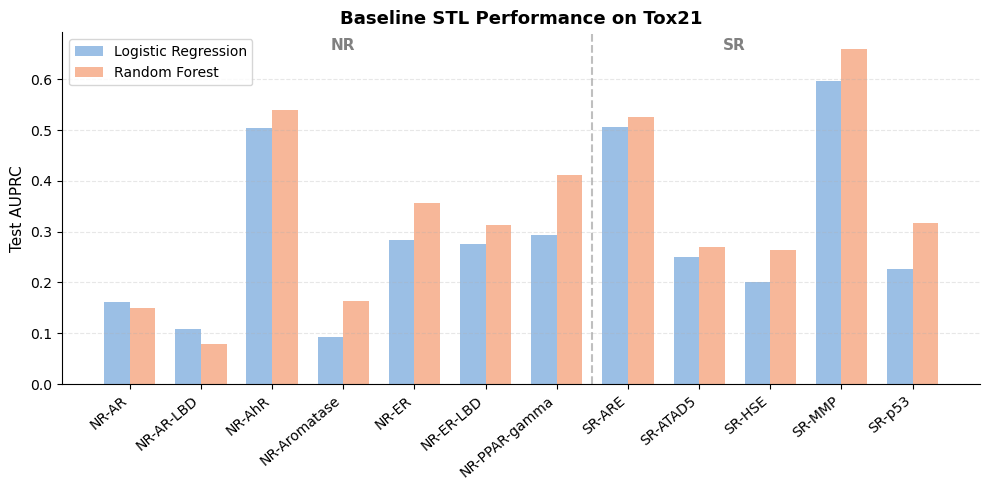

```python
# ============================================================
# Baseline Comparison Plot
# ============================================================

import matplotlib.pyplot as plt
import numpy as np

plot_df = baseline_results.pivot(index="Endpoint", columns="Model", values="AUPRC")
plot_df = plot_df.loc[ALL_ENDPOINTS]

x = np.arange(len(plot_df.index))
width = 0.36


colors = {
    "Logistic Regression": "#9BBFE5",  # light blue
    "Random Forest": "#F7B799"         # soft peach
}

fig, ax = plt.subplots(figsize=(10, 5))

ax.bar(
    x - width/2,
    plot_df["Logistic Regression"],
    width=width,
    label="Logistic Regression",
    color=colors["Logistic Regression"]
)

ax.bar(
    x + width/2,
    plot_df["Random Forest"],
    width=width,
    label="Random Forest",
    color=colors["Random Forest"]
)

# ----------------------------
# Axis & labels
# ----------------------------
ax.set_xticks(x)
ax.set_xticklabels(plot_df.index, rotation=40, ha="right", fontsize=10)

ax.set_ylabel("Test AUPRC", fontsize=11)
ax.set_title("Baseline STL Performance on Tox21", fontsize=13, weight="bold")

# ----------------------------
# NR / SR separation
# ----------------------------
nr_endpoints = [e for e in plot_df.index if e.startswith("NR")]
sr_endpoints = [e for e in plot_df.index if e.startswith("SR")]

nr_end = len(nr_endpoints) - 1

# vertical separator
ax.axvline(nr_end + 0.5, linestyle="--", color="grey", alpha=0.5)

# labels
ax.text(
    nr_end / 2,
    ax.get_ylim()[1] * 0.95,
    "NR",
    ha="center",
    fontsize=11,
    weight="bold",
    color="grey"
)

ax.text(
    nr_end + (len(sr_endpoints) / 2),
    ax.get_ylim()[1] * 0.95,
    "SR",
    ha="center",
    fontsize=11,
    weight="bold",
    color="grey"
)

# ----------------------------
# Style
# ----------------------------
ax.legend(frameon=True, fontsize=10)

ax.spines["top"].set_visible(False)
ax.spines["right"].set_visible(False)

ax.grid(axis="y", linestyle="--", alpha=0.3)

plt.tight_layout()
plt.show()
```

The baseline results show that Random Forest outperforms Logistic Regression on both metrics, achieving higher AUPRC (0.337 vs 0.291) and AUROC (0.771 vs 0.728). This suggests that nonlinear models are better able to capture complex relationships in molecular fingerprints compared to linear models.

Overall, these results confirm that Random Forest provides a stronger baseline for toxicity prediction, while Logistic Regression still serves as a simple and interpretable reference.

## 5. Graph Neural Network Models

This section introduces deep learning models to learn representations directly from molecular graphs.

```python
# ============================================================
# Torch / PyG Safe Import
# ============================================================

try:
    import torch
    import torch.nn as nn
    import torch.nn.functional as F

    from torch_geometric.data import DataLoader
    from torch_geometric.nn import GCNConv, global_mean_pool

    TORCH_AVAILABLE = True
    print("PyTorch + PyG loaded successfully.")
except Exception as e:
    TORCH_AVAILABLE = False
    print("PyTorch not available → GNN section skipped.")
    print(e)
```

```
PyTorch + PyG loaded successfully.
```

### 5.1 GCN Architecture

Define the graph convolutional network used to aggregate information from neighboring atoms.

```python
# ============================================================
# 5.1 GCN Architecture
# ============================================================

if TORCH_AVAILABLE:

    class GCN(nn.Module):
        def __init__(self, in_channels, hidden_channels, out_channels):
            super().__init__()

            self.conv1 = GCNConv(in_channels, hidden_channels)
            self.conv2 = GCNConv(hidden_channels, hidden_channels)

            self.lin = nn.Linear(hidden_channels, out_channels)

        def forward(self, x, edge_index, batch):
            x = self.conv1(x, edge_index)
            x = F.relu(x)

            x = self.conv2(x, edge_index)
            x = F.relu(x)

            x = global_mean_pool(x, batch)

            x = self.lin(x)
            return x
```

### 5.2 STL (Single-Task Learning)

Train separate GCN models for each endpoint to isolate task-specific performance.

```python
# ============================================================
# 5.2 GCN - STL
# ============================================================

if TORCH_AVAILABLE:

    def train_gcn_stl(train_graphs, test_graphs, endpoint_idx, epochs=20):
        device = torch.device("cpu")

        model = GCN(
            in_channels=train_graphs[0].x.shape[1],
            hidden_channels=64,
            out_channels=1
        ).to(device)

        optimizer = torch.optim.Adam(model.parameters(), lr=0.001)

        def filter_graphs(graphs):
            return [g for g in graphs if not torch.isnan(g.y[endpoint_idx])]

        train_graphs_f = filter_graphs(train_graphs)
        test_graphs_f  = filter_graphs(test_graphs)

        train_loader = DataLoader(train_graphs_f, batch_size=32, shuffle=True)
        test_loader  = DataLoader(test_graphs_f, batch_size=32)

        for epoch in range(epochs):
            model.train()
            for batch in train_loader:
                batch = batch.to(device)

                y = batch.y[:, endpoint_idx].unsqueeze(1)

                pred = model(batch.x, batch.edge_index, batch.batch)

                loss = F.binary_cross_entropy_with_logits(pred, y)

                optimizer.zero_grad()
                loss.backward()
                optimizer.step()

        # evaluation
        model.eval()
        y_true, y_score = [], []

        for batch in test_loader:
            batch = batch.to(device)
            pred = model(batch.x, batch.edge_index, batch.batch)

            y = batch.y[:, endpoint_idx]

            y_true.extend(y.cpu().numpy())
            y_score.extend(torch.sigmoid(pred).cpu().detach().numpy().flatten())

        return np.array(y_true), np.array(y_score)
```

### 5.3 Full MTL

Train a shared model across all endpoints to exploit potential task relationships and shared representations.

```python
# ============================================================
# 5.3 GCN - Full MTL
# ============================================================

if TORCH_AVAILABLE:

    def train_gcn_mtl(train_graphs, test_graphs, n_tasks, epochs=20):
        device = torch.device("cpu")

        model = GCN(
            in_channels=train_graphs[0].x.shape[1],
            hidden_channels=64,
            out_channels=n_tasks
        ).to(device)

        optimizer = torch.optim.Adam(model.parameters(), lr=0.001)

        train_loader = DataLoader(train_graphs, batch_size=32, shuffle=True)
        test_loader  = DataLoader(test_graphs, batch_size=32)

        for epoch in range(epochs):
            model.train()

            for batch in train_loader:
                batch = batch.to(device)

                pred = model(batch.x, batch.edge_index, batch.batch)
                y = batch.y

                mask = ~torch.isnan(y)

                loss = F.binary_cross_entropy_with_logits(
                    pred[mask],
                    y[mask]
                )

                optimizer.zero_grad()
                loss.backward()
                optimizer.step()

        # evaluation
        model.eval()
        y_true, y_score = [], []

        for batch in test_loader:
            batch = batch.to(device)

            pred = model(batch.x, batch.edge_index, batch.batch)

            y_true.append(batch.y.cpu().numpy())
            y_score.append(torch.sigmoid(pred).cpu().detach().numpy())

        return np.vstack(y_true), np.vstack(y_score)
```

### 5.4 Grouped MTL（NR vs SR）

Train models on biologically related task groups to test whether restricting task sharing improves performance.

```python
# ============================================================
# 5.4 GCN - Grouped MTL (NR / SR)
# ============================================================

NR_ENDPOINTS = [e for e in ALL_ENDPOINTS if e.startswith("NR")]
SR_ENDPOINTS = [e for e in ALL_ENDPOINTS if e.startswith("SR")]

NR_IDX = [ALL_ENDPOINTS.index(e) for e in NR_ENDPOINTS]
SR_IDX = [ALL_ENDPOINTS.index(e) for e in SR_ENDPOINTS]


if TORCH_AVAILABLE:

    def train_gcn_grouped(train_graphs, test_graphs, task_indices, epochs=20):
        device = torch.device("cpu")

        model = GCN(
            in_channels=train_graphs[0].x.shape[1],
            hidden_channels=64,
            out_channels=len(task_indices)
        ).to(device)

        optimizer = torch.optim.Adam(model.parameters(), lr=0.001)

        train_loader = DataLoader(train_graphs, batch_size=32, shuffle=True)
        test_loader  = DataLoader(test_graphs, batch_size=32)

        for epoch in range(epochs):
            model.train()

            for batch in train_loader:
                batch = batch.to(device)

                pred = model(batch.x, batch.edge_index, batch.batch)

                y = batch.y[:, task_indices]

                mask = ~torch.isnan(y)

                loss = F.binary_cross_entropy_with_logits(
                    pred[mask],
                    y[mask]
                )

                optimizer.zero_grad()
                loss.backward()
                optimizer.step()

        return model
```

Graph neural networks (GCNs) are used to learn molecular representations directly from graph structure. Unlike fingerprint-based models, GCNs operate on atoms and bonds, allowing the model to capture relational and structural information.

We evaluate three settings: single-task learning (STL), full multi-task learning (MTL), and grouped MTL based on biological categories (NR and SR). This design allows us to analyze when parameter sharing improves performance and when it leads to negative transfer.

### 6. Training Pipeline

This section defines how models are optimized and ensures stable and fair training.

### 6.1 Masked Loss for Missing Labels

Ignore missing labels during loss computation to prevent incorrect gradient updates.

```python
# ============================================================
# 6.1 Masked Loss for Missing Labels
# ============================================================

def masked_bce_with_logits_loss(logits, targets, pos_weight=None):
    """
    Binary cross-entropy with logits, ignoring missing labels (NaN).

    logits:  [batch_size, n_tasks]
    targets: [batch_size, n_tasks] or flattened equivalent
    """
    # Force targets to match logits shape
    if targets.shape != logits.shape:
        targets = targets.view_as(logits)

    mask = ~torch.isnan(targets)

    if mask.sum() == 0:
        return None

    targets_filled = torch.nan_to_num(targets, nan=0.0)

    if pos_weight is None:
        full_loss = F.binary_cross_entropy_with_logits(
            logits,
            targets_filled,
            reduction="none"
        )
    else:
        full_loss = F.binary_cross_entropy_with_logits(
            logits,
            targets_filled,
            reduction="none",
            pos_weight=pos_weight
        )

    loss = full_loss[mask].mean()
    return loss
```

```python
# ============================================================
# Helper: Build STL Graph Lists
# ============================================================

from copy import deepcopy


def select_task_subset_graphs(graph_list, task_indices):
    out = []

    for g in graph_list:
        new_g = deepcopy(g)
        new_g.y = torch.tensor(
            new_g.y[task_indices],
            dtype=torch.float32
        )
        out.append(new_g)

    return out
```

### 6.2 Class Imbalance Handling with pos_weight

Adjust the loss function to account for skewed class distributions and improve learning on rare positives.

```python
# ============================================================
# 6.2 Class Imbalance Handling with pos_weight
# ============================================================

def compute_pos_weight_from_df(df, endpoints):
    """
    Compute pos_weight = n_negative / n_positive for each endpoint
    using observed labels only.
    """
    weights = []

    for endpoint in endpoints:
        y = df[endpoint].dropna()

        n_pos = (y == 1).sum()
        n_neg = (y == 0).sum()

        if n_pos == 0:
            weight = 1.0
        else:
            weight = n_neg / n_pos

        weights.append(weight)

    return torch.tensor(weights, dtype=torch.float32)

# Example for main split
main_split_id = 0
main_split_pack = split_data[main_split_id]

train_df = main_split_pack["train"].copy()
val_df   = main_split_pack["val"].copy()
test_df  = main_split_pack["test"].copy()

pos_weight_all = compute_pos_weight_from_df(train_df, ALL_ENDPOINTS)

pos_weight_summary = pd.DataFrame({
    "Endpoint": ALL_ENDPOINTS,
    "pos_weight": pos_weight_all.numpy()
})

display(
    pos_weight_summary.style.format({
        "pos_weight": "{:.2f}"
    })
)
```

|  | Endpoint | pos_weight |
| --- | --- | --- |
| 0 | NR-AR | 21.29 |
| 1 | NR-AR-LBD | 24.88 |
| 2 | NR-AhR | 7.42 |
| 3 | NR-Aromatase | 18.51 |
| 4 | NR-ER | 6.63 |
| 5 | NR-ER-LBD | 19.02 |
| 6 | NR-PPAR-gamma | 33.46 |
| 7 | SR-ARE | 5.23 |
| 8 | SR-ATAD5 | 26.63 |
| 9 | SR-HSE | 16.58 |
| 10 | SR-MMP | 5.14 |
| 11 | SR-p53 | 15.12 |

### 6.3 Training Loop and Optimization

Implement the training process, including batching, optimization, and performance tracking.

```python
# ============================================================
# 6.3 Training Loop and Optimization
# ============================================================

from copy import deepcopy
from torch_geometric.loader import DataLoader

def train_one_epoch(model, loader, optimizer, device, pos_weight=None):
    model.train()
    total_loss = 0.0
    n_batches = 0

    for batch in loader:
        batch = batch.to(device)

        optimizer.zero_grad()

        logits = model(batch.x, batch.edge_index, batch.batch)
        targets = batch.y

        loss = masked_bce_with_logits_loss(
            logits=logits,
            targets=targets,
            pos_weight=pos_weight.to(device) if pos_weight is not None else None
        )

        if loss is None:
            continue

        loss.backward()
        optimizer.step()

        total_loss += loss.item()
        n_batches += 1

    if n_batches == 0:
        return np.nan

    return total_loss / n_batches


@torch.no_grad()
def evaluate_loss(model, loader, device, pos_weight=None):
    model.eval()
    total_loss = 0.0
    n_batches = 0

    for batch in loader:
        batch = batch.to(device)

        logits = model(batch.x, batch.edge_index, batch.batch)
        targets = batch.y

        loss = masked_bce_with_logits_loss(
            logits=logits,
            targets=targets,
            pos_weight=pos_weight.to(device) if pos_weight is not None else None
        )

        if loss is None:
            continue

        total_loss += loss.item()
        n_batches += 1

    if n_batches == 0:
        return np.nan

    return total_loss / n_batches


@torch.no_grad()
def predict_logits(model, loader, device):
    model.eval()

    all_targets = []
    all_scores = []

    for batch in loader:
        batch = batch.to(device)

        logits = model(batch.x, batch.edge_index, batch.batch)
        scores = torch.sigmoid(logits)

        targets = batch.y
        if targets.shape != logits.shape:
            targets = targets.view_as(logits)

        all_targets.append(targets.cpu())
        all_scores.append(scores.cpu())

    y_true = torch.cat(all_targets, dim=0).numpy()
    y_score = torch.cat(all_scores, dim=0).numpy()

    return y_true, y_score
```

### 6.4 Early Stopping

Stop training based on validation performance to prevent overfitting and improve generalization.

```python
# ============================================================
# 6.4 Early Stopping
# ============================================================

class EarlyStopping:
    def __init__(self, patience=10, min_delta=0.0):
        self.patience = patience
        self.min_delta = min_delta
        self.best_loss = np.inf
        self.counter = 0
        self.best_state = None

    def step(self, val_loss, model):
        if val_loss < self.best_loss - self.min_delta:
            self.best_loss = val_loss
            self.counter = 0
            self.best_state = deepcopy(model.state_dict())
            return False
        else:
            self.counter += 1
            return self.counter >= self.patience
```

### Unified Training Function

```python
# ============================================================
# Unified Training Function
# ============================================================

def fit_gcn_model(
    model,
    train_graphs,
    val_graphs,
    pos_weight=None,
    lr=1e-3,
    batch_size=32,
    max_epochs=100,
    patience=10,
    device=None
):
    if device is None:
        device = torch.device("cuda" if torch.cuda.is_available() else "cpu")

    model = model.to(device)

    train_loader = DataLoader(train_graphs, batch_size=batch_size, shuffle=True)
    val_loader   = DataLoader(val_graphs, batch_size=batch_size, shuffle=False)

    optimizer = torch.optim.Adam(model.parameters(), lr=lr)
    early_stopper = EarlyStopping(patience=patience)

    history = []

    for epoch in range(1, max_epochs + 1):
        train_loss = train_one_epoch(
            model=model,
            loader=train_loader,
            optimizer=optimizer,
            device=device,
            pos_weight=pos_weight
        )

        val_loss = evaluate_loss(
            model=model,
            loader=val_loader,
            device=device,
            pos_weight=pos_weight
        )

        history.append({
            "epoch": epoch,
            "train_loss": train_loss,
            "val_loss": val_loss
        })

        stop = early_stopper.step(val_loss, model)
        if stop:
            break

    # restore best model
    if early_stopper.best_state is not None:
        model.load_state_dict(early_stopper.best_state)

    history_df = pd.DataFrame(history)
    return model, history_df
```

```python
# ============================================================
# Sanity Check for Section 6
# ============================================================

training_summary = pd.DataFrame({
    "Component": [
        "Masked BCE loss",
        "pos_weight computation",
        "Unified training loop",
        "Early stopping"
    ],
    "Status": [
        "Ready",
        "Ready",
        "Ready",
        "Ready"
    ]
})

display(training_summary)
```

|  | Component | Status |
| --- | --- | --- |
| 0 | Masked BCE loss | Ready |
| 1 | pos_weight computation | Ready |
| 2 | Unified training loop | Ready |
| 3 | Early stopping | Ready |

The training pipeline is designed to handle the main challenges of the Tox21 dataset. Missing labels are ignored through masked loss, while class imbalance is addressed using task-specific `pos_weight` values computed from the training set.

A unified optimization loop is used for STL, full MTL, and grouped MTL models. Early stopping is applied based on validation loss to reduce overfitting and improve training stability.

### 7. Repeated Evaluation

To improve the reliability of the results, model evaluation is repeated across multiple scaffold splits and random seeds. This allows us to measure not only average performance, but also variability due to data partitioning and stochastic training effects.

Final results are reported as mean ± standard deviation. In addition, Wilcoxon signed-rank tests are used to assess whether the performance differences between STL and MTL settings are statistically significant.

```python
# ============================================================
# 7.0 Helpers
# ============================================================

import random
import numpy as np
import pandas as pd

from sklearn.metrics import average_precision_score, roc_auc_score
from scipy.stats import wilcoxon

SEEDS = [0, 1, 2]
SPLIT_IDS = list(range(len(split_data)))

NR_IDX = [ALL_ENDPOINTS.index(e) for e in NR_ENDPOINTS]
SR_IDX = [ALL_ENDPOINTS.index(e) for e in SR_ENDPOINTS]

def seed_everything(seed):
    random.seed(seed)
    np.random.seed(seed)
    torch.manual_seed(seed)
    if torch.cuda.is_available():
        torch.cuda.manual_seed_all(seed)

def safe_auprc(y_true, y_score):
    if len(np.unique(y_true)) < 2:
        return np.nan
    return average_precision_score(y_true, y_score)

def safe_auroc(y_true, y_score):
    if len(np.unique(y_true)) < 2:
        return np.nan
    return roc_auc_score(y_true, y_score)

def get_graph_lists(split_pack):
    return {
        "train": [g for g in split_pack["train"]["GraphData"] if g is not None],
        "val":   [g for g in split_pack["val"]["GraphData"] if g is not None],
        "test":  [g for g in split_pack["test"]["GraphData"] if g is not None]
    }

def compute_single_task_pos_weight(train_df, endpoint):
    y = train_df[endpoint].dropna()
    n_pos = (y == 1).sum()
    n_neg = (y == 0).sum()
    if n_pos == 0:
        return torch.tensor([1.0], dtype=torch.float32)
    return torch.tensor([n_neg / n_pos], dtype=torch.float32)

def compute_subset_pos_weight(train_df, endpoints):
    vals = []
    for endpoint in endpoints:
        y = train_df[endpoint].dropna()
        n_pos = (y == 1).sum()
        n_neg = (y == 0).sum()
        vals.append(1.0 if n_pos == 0 else n_neg / n_pos)
    return torch.tensor(vals, dtype=torch.float32)

def make_gcn(out_channels, in_channels):
    return GCN(
        in_channels=in_channels,
        hidden_channels=64,
        out_channels=out_channels
    )
```

### 7.1 Repeated Evaluation Across Splits and Seeds

```python
# ============================================================
# Repeated Evaluation Across Splits and Seeds
# ============================================================

all_results = []

for split_id in SPLIT_IDS:
    split_pack = split_data[split_id]
    graph_pack = get_graph_lists(split_pack)

    train_df = split_pack["train"]
    val_df   = split_pack["val"]
    test_df  = split_pack["test"]

    # infer input dimension once
    sample_graph = graph_pack["train"][0]
    in_channels = sample_graph.x.shape[1]

    for seed in SEEDS:
        seed_everything(seed)

        # ----------------------------------------------------
        # A. GCN-STL
        # ----------------------------------------------------
        for endpoint_idx, endpoint in enumerate(ALL_ENDPOINTS):
            train_graphs_stl = select_single_task_graphs(graph_pack["train"], endpoint_idx)
            val_graphs_stl   = select_single_task_graphs(graph_pack["val"], endpoint_idx)
            test_graphs_stl  = select_single_task_graphs(graph_pack["test"], endpoint_idx)

            if len(train_graphs_stl) == 0 or len(val_graphs_stl) == 0 or len(test_graphs_stl) == 0:
                all_results.append({
                    "split": split_id,
                    "seed": seed,
                    "model": "GCN-STL",
                    "endpoint": endpoint,
                    "group": "NR" if endpoint in NR_ENDPOINTS else "SR",
                    "AUPRC": np.nan,
                    "AUROC": np.nan
                })
                continue

            pos_weight = compute_single_task_pos_weight(train_df, endpoint)

            model = make_gcn(out_channels=1, in_channels=in_channels)

            model, history = fit_gcn_model(
                model=model,
                train_graphs=train_graphs_stl,
                val_graphs=val_graphs_stl,
                pos_weight=pos_weight,
                lr=1e-3,
                batch_size=32,
                max_epochs=100,
                patience=10
            )

            from torch_geometric.loader import DataLoader
            test_loader = DataLoader(test_graphs_stl, batch_size=32, shuffle=False)
            y_true, y_score = predict_logits(model, test_loader, device=next(model.parameters()).device)

            y_true = y_true.reshape(-1)
            y_score = y_score.reshape(-1)

            all_results.append({
                "split": split_id,
                "seed": seed,
                "model": "GCN-STL",
                "endpoint": endpoint,
                "group": "NR" if endpoint in NR_ENDPOINTS else "SR",
                "AUPRC": safe_auprc(y_true, y_score),
                "AUROC": safe_auroc(y_true, y_score)
            })

        # ----------------------------------------------------
        # B. GCN-MTL (full)
        # ----------------------------------------------------
        train_graphs_mtl = select_task_subset_graphs(graph_pack["train"], list(range(len(ALL_ENDPOINTS))))
        val_graphs_mtl   = select_task_subset_graphs(graph_pack["val"],   list(range(len(ALL_ENDPOINTS))))
        test_graphs_mtl  = select_task_subset_graphs(graph_pack["test"],  list(range(len(ALL_ENDPOINTS))))

        pos_weight_all = compute_subset_pos_weight(train_df, ALL_ENDPOINTS)

        model = make_gcn(out_channels=len(ALL_ENDPOINTS), in_channels=in_channels)

        model, history = fit_gcn_model(
            model=model,
            train_graphs=train_graphs_mtl,
            val_graphs=val_graphs_mtl,
            pos_weight=pos_weight_all,
            lr=1e-3,
            batch_size=32,
            max_epochs=100,
            patience=10
        )

        test_loader = DataLoader(test_graphs_mtl, batch_size=32, shuffle=False)
        y_true_all, y_score_all = predict_logits(model, test_loader, device=next(model.parameters()).device)

        for endpoint_idx, endpoint in enumerate(ALL_ENDPOINTS):
            mask = ~np.isnan(y_true_all[:, endpoint_idx])
            y_true = y_true_all[mask, endpoint_idx]
            y_score = y_score_all[mask, endpoint_idx]

            all_results.append({
                "split": split_id,
                "seed": seed,
                "model": "GCN-MTL",
                "endpoint": endpoint,
                "group": "NR" if endpoint in NR_ENDPOINTS else "SR",
                "AUPRC": safe_auprc(y_true, y_score),
                "AUROC": safe_auroc(y_true, y_score)
            })

        # ----------------------------------------------------
        # C. GCN-NR-MTL
        # ----------------------------------------------------
        train_graphs_nr = select_task_subset_graphs(graph_pack["train"], NR_IDX)
        val_graphs_nr   = select_task_subset_graphs(graph_pack["val"],   NR_IDX)
        test_graphs_nr  = select_task_subset_graphs(graph_pack["test"],  NR_IDX)

        pos_weight_nr = compute_subset_pos_weight(train_df, NR_ENDPOINTS)

        model = make_gcn(out_channels=len(NR_IDX), in_channels=in_channels)

        model, history = fit_gcn_model(
            model=model,
            train_graphs=train_graphs_nr,
            val_graphs=val_graphs_nr,
            pos_weight=pos_weight_nr,
            lr=1e-3,
            batch_size=32,
            max_epochs=100,
            patience=10
        )

        test_loader = DataLoader(test_graphs_nr, batch_size=32, shuffle=False)
        y_true_nr, y_score_nr = predict_logits(model, test_loader, device=next(model.parameters()).device)

        for local_idx, endpoint in enumerate(NR_ENDPOINTS):
            mask = ~np.isnan(y_true_nr[:, local_idx])
            y_true = y_true_nr[mask, local_idx]
            y_score = y_score_nr[mask, local_idx]

            all_results.append({
                "split": split_id,
                "seed": seed,
                "model": "GCN-NR-MTL",
                "endpoint": endpoint,
                "group": "NR",
                "AUPRC": safe_auprc(y_true, y_score),
                "AUROC": safe_auroc(y_true, y_score)
            })

        # ----------------------------------------------------
        # D. GCN-SR-MTL
        # ----------------------------------------------------
        train_graphs_sr = select_task_subset_graphs(graph_pack["train"], SR_IDX)
        val_graphs_sr   = select_task_subset_graphs(graph_pack["val"],   SR_IDX)
        test_graphs_sr  = select_task_subset_graphs(graph_pack["test"],  SR_IDX)

        pos_weight_sr = compute_subset_pos_weight(train_df, SR_ENDPOINTS)

        model = make_gcn(out_channels=len(SR_IDX), in_channels=in_channels)

        model, history = fit_gcn_model(
            model=model,
            train_graphs=train_graphs_sr,
            val_graphs=val_graphs_sr,
            pos_weight=pos_weight_sr,
            lr=1e-3,
            batch_size=32,
            max_epochs=100,
            patience=10
        )

        test_loader = DataLoader(test_graphs_sr, batch_size=32, shuffle=False)
        y_true_sr, y_score_sr = predict_logits(model, test_loader, device=next(model.parameters()).device)

        for local_idx, endpoint in enumerate(SR_ENDPOINTS):
            mask = ~np.isnan(y_true_sr[:, local_idx])
            y_true = y_true_sr[mask, local_idx]
            y_score = y_score_sr[mask, local_idx]

            all_results.append({
                "split": split_id,
                "seed": seed,
                "model": "GCN-SR-MTL",
                "endpoint": endpoint,
                "group": "SR",
                "AUPRC": safe_auprc(y_true, y_score),
                "AUROC": safe_auroc(y_true, y_score)
            })

results_df = pd.DataFrame(all_results)
display(results_df.head())
```

|  | split | seed | model | endpoint | group | AUPRC | AUROC |
| --- | --- | --- | --- | --- | --- | --- | --- |
| 0 | 0 | 0 | GCN-STL | NR-AR | NR | 0.277993 | 0.699125 |
| 1 | 0 | 0 | GCN-STL | NR-AR-LBD | NR | 0.028678 | 0.551474 |
| 2 | 0 | 0 | GCN-STL | NR-AhR | NR | 0.566122 | 0.867591 |
| 3 | 0 | 0 | GCN-STL | NR-Aromatase | NR | 0.130767 | 0.753445 |
| 4 | 0 | 0 | GCN-STL | NR-ER | NR | 0.254902 | 0.664575 |

### 7.3 Aggregation of Results (Mean ± Std)

### 7.3.1 model-level summary

```python
# ============================================================
# 7.3 Aggregation: Model-Level Summary
# ============================================================

model_summary = (
    results_df
    .groupby("model", as_index=False)
    .agg(
        Mean_AUPRC=("AUPRC", "mean"),
        Std_AUPRC=("AUPRC", "std"),
        Mean_AUROC=("AUROC", "mean"),
        Std_AUROC=("AUROC", "std")
    )
    .sort_values("Mean_AUPRC", ascending=False)
)

display(
    model_summary.style.format({
        "Mean_AUPRC": "{:.3f}",
        "Std_AUPRC": "{:.3f}",
        "Mean_AUROC": "{:.3f}",
        "Std_AUROC": "{:.3f}"
    })
)
```

|  | model | Mean_AUPRC | Std_AUPRC | Mean_AUROC | Std_AUROC |
| --- | --- | --- | --- | --- | --- |
| 1 | GCN-NR-MTL | 0.297 | 0.177 | 0.776 | 0.077 |
| 0 | GCN-MTL | 0.296 | 0.175 | 0.785 | 0.066 |
| 3 | GCN-STL | 0.293 | 0.184 | 0.771 | 0.076 |
| 2 | GCN-SR-MTL | 0.287 | 0.158 | 0.793 | 0.049 |

### 7.3.2 endpoint-level summary

```python
# ============================================================
# 7.3 Aggregation: Endpoint-Level Summary
# ============================================================

endpoint_summary = (
    results_df
    .groupby(["model", "endpoint", "group"], as_index=False)
    .agg(
        Mean_AUPRC=("AUPRC", "mean"),
        Std_AUPRC=("AUPRC", "std"),
        Mean_AUROC=("AUROC", "mean"),
        Std_AUROC=("AUROC", "std")
    )
)

display(
    endpoint_summary.head(20).style.format({
        "Mean_AUPRC": "{:.3f}",
        "Std_AUPRC": "{:.3f}",
        "Mean_AUROC": "{:.3f}",
        "Std_AUROC": "{:.3f}"
    })
)
```

|  | model | endpoint | group | Mean_AUPRC | Std_AUPRC | Mean_AUROC | Std_AUROC |
| --- | --- | --- | --- | --- | --- | --- | --- |
| 0 | GCN-MTL | NR-AR | NR | 0.395 | 0.185 | 0.782 | 0.077 |
| 1 | GCN-MTL | NR-AR-LBD | NR | 0.297 | 0.235 | 0.785 | 0.121 |
| 2 | GCN-MTL | NR-AhR | NR | 0.460 | 0.086 | 0.854 | 0.030 |
| 3 | GCN-MTL | NR-Aromatase | NR | 0.166 | 0.014 | 0.784 | 0.025 |
| 4 | GCN-MTL | NR-ER | NR | 0.405 | 0.110 | 0.749 | 0.041 |
| 5 | GCN-MTL | NR-ER-LBD | NR | 0.267 | 0.128 | 0.770 | 0.083 |
| 6 | GCN-MTL | NR-PPAR-gamma | NR | 0.099 | 0.039 | 0.748 | 0.050 |
| 7 | GCN-MTL | SR-ARE | SR | 0.381 | 0.093 | 0.754 | 0.045 |
| 8 | GCN-MTL | SR-ATAD5 | SR | 0.128 | 0.042 | 0.769 | 0.052 |
| 9 | GCN-MTL | SR-HSE | SR | 0.206 | 0.089 | 0.766 | 0.017 |
| 10 | GCN-MTL | SR-MMP | SR | 0.546 | 0.091 | 0.854 | 0.043 |
| 11 | GCN-MTL | SR-p53 | SR | 0.202 | 0.030 | 0.810 | 0.025 |
| 12 | GCN-NR-MTL | NR-AR | NR | 0.379 | 0.156 | 0.783 | 0.072 |
| 13 | GCN-NR-MTL | NR-AR-LBD | NR | 0.313 | 0.242 | 0.778 | 0.121 |
| 14 | GCN-NR-MTL | NR-AhR | NR | 0.459 | 0.100 | 0.852 | 0.032 |
| 15 | GCN-NR-MTL | NR-Aromatase | NR | 0.164 | 0.016 | 0.779 | 0.034 |
| 16 | GCN-NR-MTL | NR-ER | NR | 0.393 | 0.089 | 0.745 | 0.038 |
| 17 | GCN-NR-MTL | NR-ER-LBD | NR | 0.282 | 0.137 | 0.768 | 0.084 |
| 18 | GCN-NR-MTL | NR-PPAR-gamma | NR | 0.088 | 0.037 | 0.729 | 0.056 |
| 19 | GCN-SR-MTL | SR-ARE | SR | 0.380 | 0.097 | 0.756 | 0.046 |

### 7.3.3 compact “mean ± std” table

```python
# ============================================================
# 7.3 Compact Mean ± Std Table
# ============================================================

compact_summary = model_summary.copy()
compact_summary["AUPRC"] = compact_summary.apply(
    lambda r: f"{r['Mean_AUPRC']:.3f} ± {r['Std_AUPRC']:.3f}", axis=1
)
compact_summary["AUROC"] = compact_summary.apply(
    lambda r: f"{r['Mean_AUROC']:.3f} ± {r['Std_AUROC']:.3f}", axis=1
)

compact_summary = compact_summary[["model", "AUPRC", "AUROC"]]
display(compact_summary)
```

|  | model | AUPRC | AUROC |
| --- | --- | --- | --- |
| 1 | GCN-NR-MTL | 0.297 ± 0.177 | 0.776 ± 0.077 |
| 0 | GCN-MTL | 0.296 ± 0.175 | 0.785 ± 0.066 |
| 3 | GCN-STL | 0.293 ± 0.184 | 0.771 ± 0.076 |
| 2 | GCN-SR-MTL | 0.287 ± 0.158 | 0.793 ± 0.049 |

### 7.4 Wilcoxon Signed-Rank Test

```python
# ============================================================
# 7.4 Wilcoxon Signed-Rank Test
# ============================================================

def paired_metric_df(results_df, model_a, model_b, endpoints=None, metric="AUPRC"):
    sub = results_df.copy()

    if endpoints is not None:
        sub = sub[sub["endpoint"].isin(endpoints)]

    a = sub[sub["model"] == model_a][["split", "seed", "endpoint", metric]].rename(columns={metric: f"{model_a}_{metric}"})
    b = sub[sub["model"] == model_b][["split", "seed", "endpoint", metric]].rename(columns={metric: f"{model_b}_{metric}"})

    merged = a.merge(b, on=["split", "seed", "endpoint"], how="inner").dropna()
    return merged

def run_wilcoxon(results_df, model_a, model_b, endpoints=None, metric="AUPRC"):
    paired = paired_metric_df(results_df, model_a, model_b, endpoints=endpoints, metric=metric)

    if len(paired) == 0:
        return {
            "Comparison": f"{model_a} vs {model_b}",
            "Metric": metric,
            "N": 0,
            "Statistic": np.nan,
            "p-value": np.nan
        }

    x = paired[f"{model_a}_{metric}"].values
    y = paired[f"{model_b}_{metric}"].values

    if np.allclose(x, y):
        stat, p = np.nan, 1.0
    else:
        stat, p = wilcoxon(x, y, zero_method="wilcox", alternative="two-sided")

    return {
        "Comparison": f"{model_a} vs {model_b}",
        "Metric": metric,
        "N": len(paired),
        "Statistic": stat,
        "p-value": p
    }

wilcoxon_rows = [
    run_wilcoxon(results_df, "GCN-MTL", "GCN-STL", endpoints=ALL_ENDPOINTS, metric="AUPRC"),
    run_wilcoxon(results_df, "GCN-MTL", "GCN-STL", endpoints=ALL_ENDPOINTS, metric="AUROC"),
    run_wilcoxon(results_df, "GCN-NR-MTL", "GCN-STL", endpoints=NR_ENDPOINTS, metric="AUPRC"),
    run_wilcoxon(results_df, "GCN-SR-MTL", "GCN-STL", endpoints=SR_ENDPOINTS, metric="AUPRC"),
]

wilcoxon_df = pd.DataFrame(wilcoxon_rows)

display(
    wilcoxon_df.style.format({
        "Statistic": "{:.3f}",
        "p-value": "{:.4f}"
    })
)
```

|  | Comparison | Metric | N | Statistic | p-value |
| --- | --- | --- | --- | --- | --- |
| 0 | GCN-MTL vs GCN-STL | AUPRC | 180 | 7904.000 | 0.7306 |
| 1 | GCN-MTL vs GCN-STL | AUROC | 180 | 5180.000 | 0.0000 |
| 2 | GCN-NR-MTL vs GCN-STL | AUPRC | 105 | 2684.000 | 0.7528 |
| 3 | GCN-SR-MTL vs GCN-STL | AUPRC | 75 | 1115.000 | 0.1016 |

## 8. Transfer Analysis

This section analyzes transfer effects by comparing MTL against STL at the endpoint level. Transfer gain is defined as ΔAUPRC = AUPRC(MTL) − AUPRC(STL). Positive values indicate positive transfer, while negative values indicate negative transfer.

### 8.1 Computing Transfer Gain (ΔAUPRC = MTL − STL)

```python
# ============================================================
# 8.1 Computing Transfer Gain (ΔAUPRC = MTL − STL)
# ============================================================

metric = "AUPRC"

stl_df = (
    results_df[results_df["model"] == "GCN-STL"]
    [["split", "seed", "endpoint", metric]]
    .rename(columns={metric: "AUPRC_STL"})
)

mtl_df = (
    results_df[results_df["model"] == "GCN-MTL"]
    [["split", "seed", "endpoint", metric]]
    .rename(columns={metric: "AUPRC_MTL"})
)

transfer_df = stl_df.merge(
    mtl_df,
    on=["split", "seed", "endpoint"],
    how="inner"
)

transfer_df["TransferGain"] = transfer_df["AUPRC_MTL"] - transfer_df["AUPRC_STL"]
transfer_df["Group"] = transfer_df["endpoint"].apply(
    lambda x: "NR" if x in NR_ENDPOINTS else "SR"
)

display(transfer_df.head())
```

|  | split | seed | endpoint | AUPRC_STL | AUPRC_MTL | TransferGain | Group |
| --- | --- | --- | --- | --- | --- | --- | --- |
| 0 | 0 | 0 | NR-AR | 0.277993 | 0.203086 | -0.074907 | NR |
| 1 | 0 | 0 | NR-AR-LBD | 0.028678 | 0.036832 | 0.008154 | NR |
| 2 | 0 | 0 | NR-AhR | 0.566122 | 0.544451 | -0.021670 | NR |
| 3 | 0 | 0 | NR-Aromatase | 0.130767 | 0.168236 | 0.037469 | NR |
| 4 | 0 | 0 | NR-ER | 0.254902 | 0.381261 | 0.126359 | NR |

### 8.2 Endpoint-Level Transfer Classification

```python
# ============================================================
# 8.2 Endpoint-Level Transfer Classification
# ============================================================

endpoint_transfer = (
    transfer_df
    .groupby(["endpoint", "Group"], as_index=False)
    .agg(
        Mean_TransferGain=("TransferGain", "mean"),
        Std_TransferGain=("TransferGain", "std"),
        Mean_AUPRC_STL=("AUPRC_STL", "mean"),
        Mean_AUPRC_MTL=("AUPRC_MTL", "mean")
    )
)

def classify_transfer(x):
    if x > 0:
        return "Positive transfer"
    elif x < 0:
        return "Negative transfer"
    else:
        return "No change"

endpoint_transfer["TransferType"] = endpoint_transfer["Mean_TransferGain"].apply(classify_transfer)

endpoint_transfer = endpoint_transfer.sort_values("Mean_TransferGain").reset_index(drop=True)

display(
    endpoint_transfer.style.format({
        "Mean_TransferGain": "{:.3f}",
        "Std_TransferGain": "{:.3f}",
        "Mean_AUPRC_STL": "{:.3f}",
        "Mean_AUPRC_MTL": "{:.3f}"
    })
)
```

|  | endpoint | Group | Mean_TransferGain | Std_TransferGain | Mean_AUPRC_STL | Mean_AUPRC_MTL | TransferType |
| --- | --- | --- | --- | --- | --- | --- | --- |
| 0 | NR-AhR | NR | -0.038 | 0.056 | 0.498 | 0.460 | Negative transfer |
| 1 | SR-MMP | SR | -0.031 | 0.044 | 0.576 | 0.546 | Negative transfer |
| 2 | NR-ER-LBD | NR | -0.027 | 0.051 | 0.294 | 0.267 | Negative transfer |
| 3 | SR-ARE | SR | -0.018 | 0.045 | 0.399 | 0.381 | Negative transfer |
| 4 | NR-Aromatase | NR | -0.007 | 0.033 | 0.173 | 0.166 | Negative transfer |
| 5 | SR-ATAD5 | SR | 0.000 | 0.025 | 0.128 | 0.128 | Positive transfer |
| 6 | NR-PPAR-gamma | NR | 0.006 | 0.045 | 0.093 | 0.099 | Positive transfer |
| 7 | SR-HSE | SR | 0.011 | 0.043 | 0.195 | 0.206 | Positive transfer |
| 8 | SR-p53 | SR | 0.014 | 0.036 | 0.187 | 0.202 | Positive transfer |
| 9 | NR-AR-LBD | NR | 0.031 | 0.064 | 0.266 | 0.297 | Positive transfer |
| 10 | NR-AR | NR | 0.046 | 0.096 | 0.350 | 0.395 | Positive transfer |
| 11 | NR-ER | NR | 0.049 | 0.057 | 0.356 | 0.405 | Positive transfer |

### 8.3 NR vs SR Group-Level Analysis

```python
# ============================================================
# 8.3 NR vs SR Group-Level Analysis
# ============================================================

group_transfer = (
    endpoint_transfer
    .groupby("Group", as_index=False)
    .agg(
        Mean_TransferGain=("Mean_TransferGain", "mean"),
        Median_TransferGain=("Mean_TransferGain", "median"),
        Positive_Endpoints=("TransferType", lambda x: (x == "Positive transfer").sum()),
        Negative_Endpoints=("TransferType", lambda x: (x == "Negative transfer").sum()),
        Total_Endpoints=("endpoint", "count")
    )
)

display(
    group_transfer.style.format({
        "Mean_TransferGain": "{:.3f}",
        "Median_TransferGain": "{:.3f}"
    })
)
```

|  | Group | Mean_TransferGain | Median_TransferGain | Positive_Endpoints | Negative_Endpoints | Total_Endpoints |
| --- | --- | --- | --- | --- | --- | --- |
| 0 | NR | 0.009 | 0.006 | 4 | 3 | 7 |
| 1 | SR | -0.005 | 0.000 | 3 | 2 | 5 |

```python
# ============================================================
# 8.4 Transfer Gain vs Phi Similarity (FIXED)
# ============================================================

# Step 1: convert FIRST
phi_matrix = pd.DataFrame(
    phi_matrix,
    index=ALL_ENDPOINTS,
    columns=ALL_ENDPOINTS
)

# Step 2: compute mean phi
phi_mean_rows = []

for endpoint in ALL_ENDPOINTS:
    other_eps = [e for e in ALL_ENDPOINTS if e != endpoint]
    mean_phi = phi_matrix.loc[endpoint, other_eps].mean()

    phi_mean_rows.append({
        "endpoint": endpoint,
        "MeanPhiToOthers": mean_phi
    })

phi_mean_df = pd.DataFrame(phi_mean_rows)
```

### 8.5 Transfer Gain vs Sparsity and Imbalance

```python
# ============================================================
# 8.5 Transfer Gain vs Sparsity and Imbalance
# ============================================================

# From Section 1.4
coverage_df = missing_df[["Endpoint", "Coverage"]].rename(columns={"Endpoint": "endpoint"})

# From Section 1.5
imbalance_summary_df = imbalance_df[["Endpoint", "Positive rate"]].rename(columns={"Endpoint": "endpoint"})

endpoint_transfer = endpoint_transfer.merge(coverage_df, on="endpoint", how="left")
endpoint_transfer = endpoint_transfer.merge(imbalance_summary_df, on="endpoint", how="left")

corr_coverage = endpoint_transfer["Mean_TransferGain"].corr(endpoint_transfer["Coverage"])
corr_posrate  = endpoint_transfer["Mean_TransferGain"].corr(endpoint_transfer["Positive rate"])

transfer_factor_summary = endpoint_transfer[[
    "endpoint", "Group", "Mean_TransferGain", "Coverage", "Positive rate", "TransferType"
]].sort_values("Mean_TransferGain")

display(
    transfer_factor_summary.style.format({
        "Mean_TransferGain": "{:.3f}",
        "Coverage": "{:.3f}",
        "Positive rate": "{:.3f}"
    })
)

print(f"Correlation between transfer gain and label coverage: {corr_coverage:.3f}")
print(f"Correlation between transfer gain and positive rate: {corr_posrate:.3f}")
```

|  | endpoint | Group | Mean_TransferGain | Coverage | Positive rate | TransferType |
| --- | --- | --- | --- | --- | --- | --- |
| 0 | NR-AhR | NR | -0.038 | 0.835 | 0.119 | Negative transfer |
| 1 | SR-MMP | SR | -0.031 | 0.740 | 0.159 | Negative transfer |
| 2 | NR-ER-LBD | NR | -0.027 | 0.888 | 0.051 | Negative transfer |
| 3 | SR-ARE | SR | -0.018 | 0.744 | 0.161 | Negative transfer |
| 4 | NR-Aromatase | NR | -0.007 | 0.739 | 0.050 | Negative transfer |
| 5 | SR-ATAD5 | SR | 0.000 | 0.902 | 0.038 | Positive transfer |
| 6 | NR-PPAR-gamma | NR | 0.006 | 0.822 | 0.029 | Positive transfer |
| 7 | SR-HSE | SR | 0.011 | 0.825 | 0.057 | Positive transfer |
| 8 | SR-p53 | SR | 0.014 | 0.865 | 0.063 | Positive transfer |
| 9 | NR-AR-LBD | NR | 0.031 | 0.862 | 0.036 | Positive transfer |
| 10 | NR-AR | NR | 0.046 | 0.926 | 0.043 | Positive transfer |
| 11 | NR-ER | NR | 0.049 | 0.791 | 0.129 | Positive transfer |

```
Correlation between transfer gain and label coverage: 0.347
Correlation between transfer gain and positive rate: -0.367
```

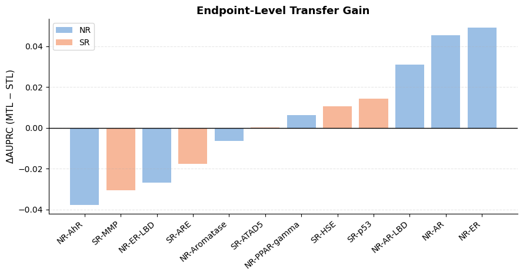

```python
# ============================================================
# Transfer Gain Plot
# ============================================================

import matplotlib.pyplot as plt
import numpy as np

plot_df = endpoint_transfer.sort_values("Mean_TransferGain").copy()

colors = plot_df["Group"].map({"NR": "#9BBFE5", "SR": "#F7B799"})

fig, ax = plt.subplots(figsize=(9, 4.8))

ax.bar(
    plot_df["endpoint"],
    plot_df["Mean_TransferGain"],
    color=colors,
    edgecolor="none"
)

ax.axhline(0, color="black", linewidth=1)

ax.set_ylabel("ΔAUPRC (MTL − STL)", fontsize=11)
ax.set_title("Endpoint-Level Transfer Gain", fontsize=13, weight="bold")
ax.set_xticklabels(plot_df["endpoint"], rotation=40, ha="right", fontsize=10)

ax.spines["top"].set_visible(False)
ax.spines["right"].set_visible(False)
ax.grid(axis="y", linestyle="--", alpha=0.3)

# legend
from matplotlib.patches import Patch
legend_handles = [
    Patch(facecolor="#9BBFE5", label="NR"),
    Patch(facecolor="#F7B799", label="SR")
]
ax.legend(handles=legend_handles, frameon=True, fontsize=10)

plt.tight_layout()
plt.show()
```

### 9. Visualization

### 9.1 Baseline Comparison Plots

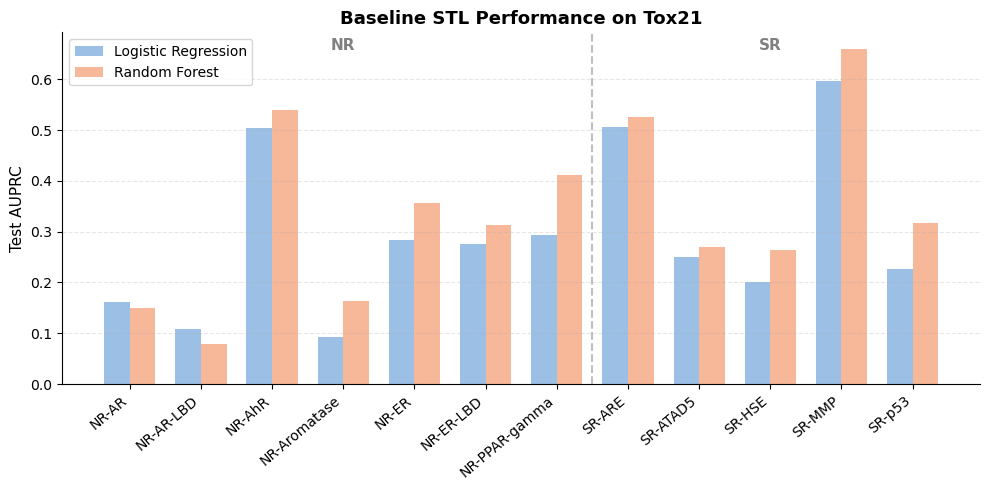

```python
# ============================================================
# 9.1 Baseline Comparison Plots
# ============================================================

import matplotlib.pyplot as plt
import numpy as np
import pandas as pd
from matplotlib.patches import Patch

plot_df = baseline_results.pivot(index="Endpoint", columns="Model", values="AUPRC")
plot_df = plot_df.loc[ALL_ENDPOINTS]

x = np.arange(len(plot_df.index))
width = 0.36

colors = {
    "Logistic Regression": "#9BBFE5",
    "Random Forest": "#F7B799"
}

fig, ax = plt.subplots(figsize=(10, 5))

ax.bar(
    x - width / 2,
    plot_df["Logistic Regression"],
    width=width,
    label="Logistic Regression",
    color=colors["Logistic Regression"]
)

ax.bar(
    x + width / 2,
    plot_df["Random Forest"],
    width=width,
    label="Random Forest",
    color=colors["Random Forest"]
)

ax.set_xticks(x)
ax.set_xticklabels(plot_df.index, rotation=40, ha="right", fontsize=10)
ax.set_ylabel("Test AUPRC", fontsize=11)
ax.set_title("Baseline STL Performance on Tox21", fontsize=13, weight="bold")

nr_end = len(NR_ENDPOINTS) - 1
ax.axvline(nr_end + 0.5, linestyle="--", color="grey", alpha=0.5)

ylim_top = ax.get_ylim()[1]
ax.text(nr_end / 2, ylim_top * 0.95, "NR", ha="center", fontsize=11, weight="bold", color="grey")
ax.text(nr_end + 1 + (len(SR_ENDPOINTS) - 1) / 2, ylim_top * 0.95, "SR", ha="center", fontsize=11, weight="bold", color="grey")

ax.legend(frameon=True, fontsize=10)
ax.spines["top"].set_visible(False)
ax.spines["right"].set_visible(False)
ax.grid(axis="y", linestyle="--", alpha=0.3)

plt.tight_layout()
plt.show()
```

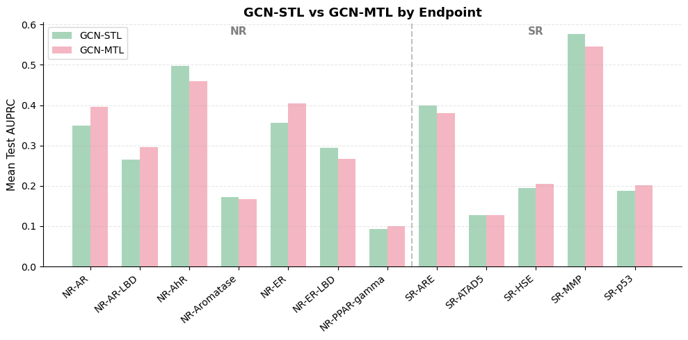

```python
# ============================================================
# 9.2 STL vs MTL Comparison
# ============================================================

# Build endpoint-level STL/MTL summary if not already available
stl_mtl_compare = (
    results_df[results_df["model"].isin(["GCN-STL", "GCN-MTL"])]
    .groupby(["model", "endpoint"], as_index=False)
    .agg(
        Mean_AUPRC=("AUPRC", "mean"),
        Std_AUPRC=("AUPRC", "std")
    )
)

plot_df = stl_mtl_compare.pivot(index="endpoint", columns="model", values="Mean_AUPRC")
plot_df = plot_df.loc[ALL_ENDPOINTS]

x = np.arange(len(plot_df.index))
width = 0.36

colors = {
    "GCN-STL": "#A8D5BA",
    "GCN-MTL": "#F4B6C2"
}

fig, ax = plt.subplots(figsize=(10, 5))

ax.bar(
    x - width / 2,
    plot_df["GCN-STL"],
    width=width,
    label="GCN-STL",
    color=colors["GCN-STL"]
)

ax.bar(
    x + width / 2,
    plot_df["GCN-MTL"],
    width=width,
    label="GCN-MTL",
    color=colors["GCN-MTL"]
)

ax.set_xticks(x)
ax.set_xticklabels(plot_df.index, rotation=40, ha="right", fontsize=10)
ax.set_ylabel("Mean Test AUPRC", fontsize=11)
ax.set_title("GCN-STL vs GCN-MTL by Endpoint", fontsize=13, weight="bold")

nr_end = len(NR_ENDPOINTS) - 1
ax.axvline(nr_end + 0.5, linestyle="--", color="grey", alpha=0.5)

ylim_top = ax.get_ylim()[1]
ax.text(nr_end / 2, ylim_top * 0.95, "NR", ha="center", fontsize=11, weight="bold", color="grey")
ax.text(nr_end + 1 + (len(SR_ENDPOINTS) - 1) / 2, ylim_top * 0.95, "SR", ha="center", fontsize=11, weight="bold", color="grey")

ax.legend(frameon=True, fontsize=10)
ax.spines["top"].set_visible(False)
ax.spines["right"].set_visible(False)
ax.grid(axis="y", linestyle="--", alpha=0.3)

plt.tight_layout()
plt.show()
```

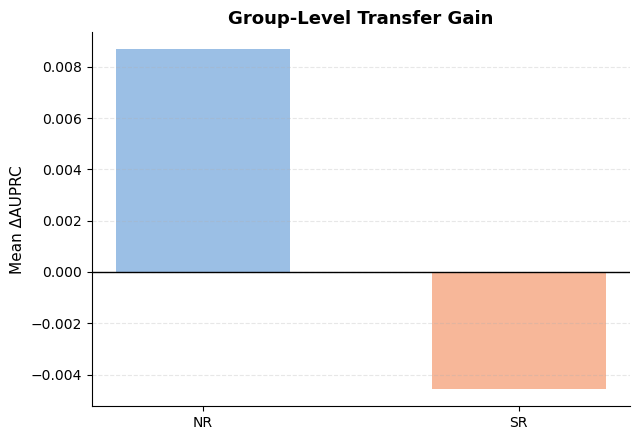

```python
# ============================================================
# 9.3 Group-Level Bar Plots
# ============================================================

# If not available, rebuild from endpoint_transfer
if "group_transfer" not in globals():
    group_transfer = (
        endpoint_transfer
        .groupby("Group", as_index=False)
        .agg(
            Mean_TransferGain=("Mean_TransferGain", "mean"),
            Median_TransferGain=("Mean_TransferGain", "median"),
            Positive_Endpoints=("TransferType", lambda x: (x == "Positive transfer").sum()),
            Negative_Endpoints=("TransferType", lambda x: (x == "Negative transfer").sum()),
            Total_Endpoints=("endpoint", "count")
        )
    )

fig, ax = plt.subplots(figsize=(6.5, 4.5))

bars = ax.bar(
    group_transfer["Group"],
    group_transfer["Mean_TransferGain"],
    color=["#9BBFE5", "#F7B799"],
    width=0.55
)

ax.axhline(0, color="black", linewidth=1)
ax.set_ylabel("Mean ΔAUPRC", fontsize=11)
ax.set_title("Group-Level Transfer Gain", fontsize=13, weight="bold")

ax.spines["top"].set_visible(False)
ax.spines["right"].set_visible(False)
ax.grid(axis="y", linestyle="--", alpha=0.3)

plt.tight_layout()
plt.show()
```

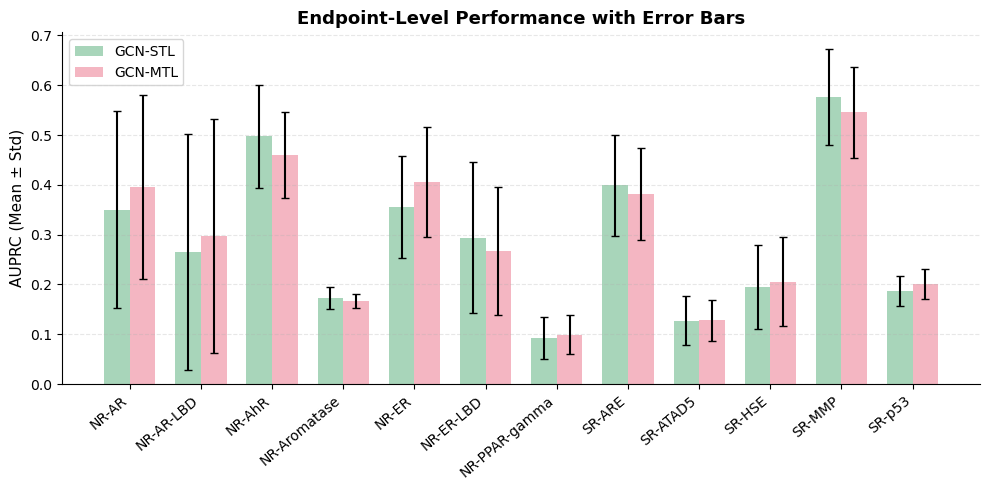

```python
# ============================================================
# 9.4 Error Bars (Mean ± Std)
# ============================================================

# Prepare endpoint summary if needed
if "endpoint_summary" not in globals():
    endpoint_summary = (
        results_df
        .groupby(["model", "endpoint", "group"], as_index=False)
        .agg(
            Mean_AUPRC=("AUPRC", "mean"),
            Std_AUPRC=("AUPRC", "std")
        )
    )

plot_df = endpoint_summary[endpoint_summary["model"].isin(["GCN-STL", "GCN-MTL"])].copy()

stl_df = plot_df[plot_df["model"] == "GCN-STL"].set_index("endpoint").loc[ALL_ENDPOINTS]
mtl_df = plot_df[plot_df["model"] == "GCN-MTL"].set_index("endpoint").loc[ALL_ENDPOINTS]

x = np.arange(len(ALL_ENDPOINTS))
width = 0.36

fig, ax = plt.subplots(figsize=(10, 5))

ax.bar(
    x - width / 2,
    stl_df["Mean_AUPRC"],
    width=width,
    yerr=stl_df["Std_AUPRC"],
    capsize=3,
    color="#A8D5BA",
    label="GCN-STL"
)

ax.bar(
    x + width / 2,
    mtl_df["Mean_AUPRC"],
    width=width,
    yerr=mtl_df["Std_AUPRC"],
    capsize=3,
    color="#F4B6C2",
    label="GCN-MTL"
)

ax.set_xticks(x)
ax.set_xticklabels(ALL_ENDPOINTS, rotation=40, ha="right", fontsize=10)
ax.set_ylabel("AUPRC (Mean ± Std)", fontsize=11)
ax.set_title("Endpoint-Level Performance with Error Bars", fontsize=13, weight="bold")

ax.spines["top"].set_visible(False)
ax.spines["right"].set_visible(False)
ax.grid(axis="y", linestyle="--", alpha=0.3)
ax.legend(frameon=True, fontsize=10)

plt.tight_layout()
plt.show()
```

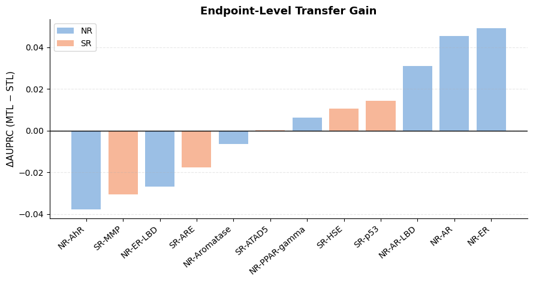

```python
# ============================================================
# 9.5 Endpoint-Level Transfer Gain
# ============================================================

plot_df = endpoint_transfer.sort_values("Mean_TransferGain").copy()

group_colors = {
    "NR": "#9BBFE5",
    "SR": "#F7B799"
}

fig, ax = plt.subplots(figsize=(9, 4.8))

ax.bar(
    plot_df["endpoint"],
    plot_df["Mean_TransferGain"],
    color=plot_df["Group"].map(group_colors),
    edgecolor="none"
)

ax.axhline(0, color="black", linewidth=1)
ax.set_ylabel("ΔAUPRC (MTL − STL)", fontsize=11)
ax.set_title("Endpoint-Level Transfer Gain", fontsize=13, weight="bold")
ax.set_xticklabels(plot_df["endpoint"], rotation=40, ha="right", fontsize=10)

ax.spines["top"].set_visible(False)
ax.spines["right"].set_visible(False)
ax.grid(axis="y", linestyle="--", alpha=0.3)

legend_handles = [
    Patch(facecolor="#9BBFE5", label="NR"),
    Patch(facecolor="#F7B799", label="SR")
]
ax.legend(handles=legend_handles, frameon=True, fontsize=10)

plt.tight_layout()
plt.show()
```

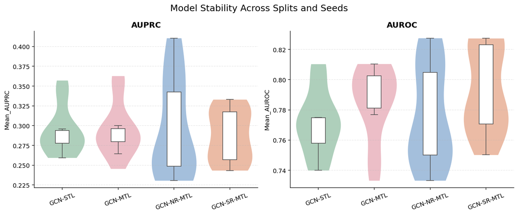

```python
# ============================================================
# Violin + Box Hybrid Plot (Publication Style)
# ============================================================

import matplotlib.pyplot as plt
import seaborn as sns
import pandas as pd

seed_plot_df = (
    results_df
    .groupby(["model", "split", "seed"], as_index=False)
    .agg(
        Mean_AUPRC=("AUPRC", "mean"),
        Mean_AUROC=("AUROC", "mean")
    )
)

order = ["GCN-STL", "GCN-MTL", "GCN-NR-MTL", "GCN-SR-MTL"]

colors = {
    "GCN-STL": "#A8D5BA",
    "GCN-MTL": "#F4B6C2",
    "GCN-NR-MTL": "#9BBFE5",
    "GCN-SR-MTL": "#F7B799"
}
palette = [colors[m] for m in order]

fig, axes = plt.subplots(1, 2, figsize=(12, 5), dpi=140)

for ax, metric, title in zip(
    axes,
    ["Mean_AUPRC", "Mean_AUROC"],
    ["AUPRC", "AUROC"]
):
    sns.violinplot(
        data=seed_plot_df,
        x="model",
        y=metric,
        order=order,
        palette=palette,
        inner=None,
        cut=0,
        linewidth=0,
        ax=ax
    )

    sns.boxplot(
        data=seed_plot_df,
        x="model",
        y=metric,
        order=order,
        width=0.25,
        showcaps=True,
        boxprops={'facecolor':'white', 'zorder':3},
        showfliers=False,
        whiskerprops={'linewidth':1},
        ax=ax
    )

    ax.set_title(title, fontsize=13, weight="bold")
    ax.set_xlabel("")
    ax.tick_params(axis="x", rotation=20)
    ax.grid(axis="y", linestyle="--", alpha=0.3)

    ax.spines["top"].set_visible(False)
    ax.spines["right"].set_visible(False)

fig.suptitle("Model Stability Across Splits and Seeds", fontsize=15)
plt.tight_layout()
plt.show()
```

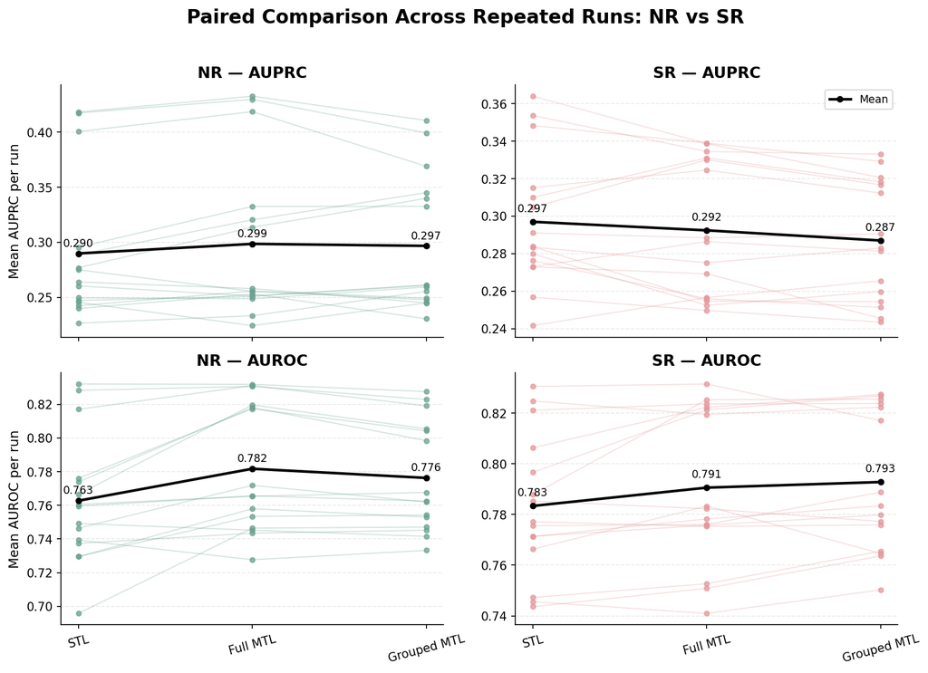

```python
# ============================================================
# Paired comparison plot by group (NR / SR): AUPRC + AUROC
# ============================================================

import matplotlib.pyplot as plt
import pandas as pd

# ----------------------------
# 1. Keep only relevant models and groups
# ----------------------------
plot_df = results_df.copy()

def map_model_family(model):
    if model == "GCN-STL":
        return "STL"
    elif model == "GCN-MTL":
        return "Full MTL"
    elif model in ["GCN-NR-MTL", "GCN-SR-MTL"]:
        return "Grouped MTL"
    else:
        return model

plot_df["ModelFamily"] = plot_df["model"].apply(map_model_family)

# Keep only meaningful combinations
plot_df = plot_df[
    ((plot_df["group"] == "NR") & (plot_df["model"].isin(["GCN-STL", "GCN-MTL", "GCN-NR-MTL"]))) |
    ((plot_df["group"] == "SR") & (plot_df["model"].isin(["GCN-STL", "GCN-MTL", "GCN-SR-MTL"])))
].copy()

# ----------------------------
# 2. Aggregate to one value per run
# ----------------------------
paired_df = (
    plot_df
    .groupby(["split", "seed", "group", "ModelFamily"], as_index=False)
    .agg(
        AUPRC=("AUPRC", "mean"),
        AUROC=("AUROC", "mean")
    )
)

paired_auprc = paired_df.pivot_table(
    index=["split", "seed", "group"],
    columns="ModelFamily",
    values="AUPRC"
).reset_index()

paired_auroc = paired_df.pivot_table(
    index=["split", "seed", "group"],
    columns="ModelFamily",
    values="AUROC"
).reset_index()

# ----------------------------
# 3. Plot settings
# ----------------------------
group_colors = {
    "NR": "#6BA292",
    "SR": "#E5989B"
}

model_order = ["STL", "Full MTL", "Grouped MTL"]
x_positions = [0, 1, 2]

TITLE_SIZE = 16
PANEL_TITLE_SIZE = 13
AXIS_LABEL_SIZE = 11
TICK_SIZE = 10
ANNOT_SIZE = 9

fig, axes = plt.subplots(2, 2, figsize=(11, 8), dpi=150, sharex=True)

# axes:
# [0,0] NR AUPRC
# [0,1] SR AUPRC
# [1,0] NR AUROC
# [1,1] SR AUROC

panel_map = [
    (axes[0, 0], paired_auprc, "NR", "AUPRC"),
    (axes[0, 1], paired_auprc, "SR", "AUPRC"),
    (axes[1, 0], paired_auroc, "NR", "AUROC"),
    (axes[1, 1], paired_auroc, "SR", "AUROC"),
]

for ax, df_metric, group, metric_name in panel_map:
    sub = df_metric[df_metric["group"] == group].copy()

    # paired lines for repeated runs
    for _, row in sub.iterrows():
        yvals = [row[m] for m in model_order]
        ax.plot(
            x_positions,
            yvals,
            color=group_colors[group],
            alpha=0.28,
            linewidth=1
        )
        ax.scatter(
            x_positions,
            yvals,
            color=group_colors[group],
            s=16,
            alpha=0.75
        )

    # mean trend
    mean_vals = [sub[m].mean() for m in model_order]
    ax.plot(
        x_positions,
        mean_vals,
        color="black",
        linewidth=2.2,
        marker="o",
        markersize=4.5,
        label="Mean"
    )

    # mean labels
    for x, y in zip(x_positions, mean_vals):
        ax.text(
            x,
            y + (0.004 if metric_name == "AUPRC" else 0.003),
            f"{y:.3f}",
            ha="center",
            va="bottom",
            fontsize=ANNOT_SIZE
        )

    ax.set_title(f"{group} — {metric_name}", fontsize=PANEL_TITLE_SIZE, weight="bold")
    ax.grid(axis="y", linestyle="--", alpha=0.25)
    ax.spines["top"].set_visible(False)
    ax.spines["right"].set_visible(False)
    ax.tick_params(axis="both", labelsize=TICK_SIZE)

# x-axis labels on bottom row
for ax in axes[1, :]:
    ax.set_xticks(x_positions)
    ax.set_xticklabels(model_order, rotation=15, fontsize=TICK_SIZE)

# also show top row labels for readability
for ax in axes[0, :]:
    ax.set_xticks(x_positions)
    ax.set_xticklabels(model_order, rotation=15, fontsize=TICK_SIZE)

axes[0, 0].set_ylabel("Mean AUPRC per run", fontsize=AXIS_LABEL_SIZE)
axes[1, 0].set_ylabel("Mean AUROC per run", fontsize=AXIS_LABEL_SIZE)

axes[0, 1].legend(frameon=True, fontsize=9, loc="best")

fig.suptitle(
    "Paired Comparison Across Repeated Runs: NR vs SR",
    fontsize=TITLE_SIZE,
    weight="bold",
    y=0.98
)

plt.tight_layout(rect=[0, 0, 1, 0.96])
plt.show()
```

Interestingly, we observe divergent trends between AUPRC and AUROC on SR endpoints. While AUROC improves with multi-task learning, AUPRC slightly decreases.

This suggests that multi-task learning improves the global ranking of predictions, but does not translate into better precision-recall performance under severe class imbalance. In other words, although positive samples are ranked higher on average, the model produces more false positives, reducing precision.

This highlights the importance of evaluating both AUROC and AUPRC, especially for imbalanced toxicity datasets such as Tox21.

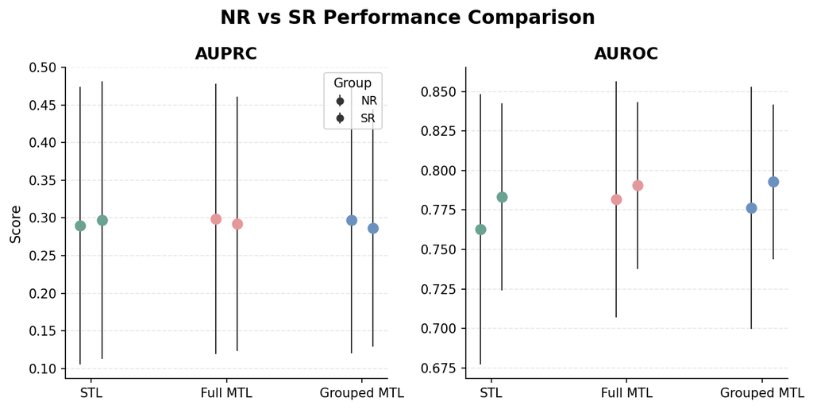

```python
# ============================================================
# Clean comparison: NR vs SR (AUPRC + AUROC)
# ============================================================

import matplotlib.pyplot as plt
import numpy as np
import pandas as pd

# ----------------------------
# Aggregate
# ----------------------------
summary_df = (
    results_df
    .groupby(["group", "model"], as_index=False)
    .agg(
        AUPRC_mean=("AUPRC", "mean"),
        AUPRC_std=("AUPRC", "std"),
        AUROC_mean=("AUROC", "mean"),
        AUROC_std=("AUROC", "std")
    )
)

# Map model names
model_map = {
    "GCN-STL": "STL",
    "GCN-MTL": "Full MTL",
    "GCN-NR-MTL": "Grouped MTL",
    "GCN-SR-MTL": "Grouped MTL"
}

summary_df["Model"] = summary_df["model"].map(model_map)

# remove duplicates (NR-MTL vs SR-MTL) using numeric columns only
summary_df = (
    summary_df
    .groupby(["group", "Model"], as_index=False)[
        ["AUPRC_mean", "AUPRC_std", "AUROC_mean", "AUROC_std"]
    ]
    .mean()
)

# ----------------------------
# Plot
# ----------------------------
fig, axes = plt.subplots(1, 2, figsize=(9, 4.5), dpi=150)

colors = {
    "STL": "#6BA292",
    "Full MTL": "#E5989B",
    "Grouped MTL": "#6C91BF"
}

model_order = ["STL", "Full MTL", "Grouped MTL"]
x = np.arange(len(model_order))

for ax, metric, title in zip(
    axes,
    ["AUPRC", "AUROC"],
    ["AUPRC", "AUROC"]
):
    for group, shift in zip(["NR", "SR"], [-0.08, 0.08]):
        sub = summary_df[summary_df["group"] == group].copy()
        sub = sub.set_index("Model").loc[model_order]

        means = sub[f"{metric}_mean"]
        stds = sub[f"{metric}_std"]

        ax.errorbar(
            x + shift,
            means,
            yerr=stds,
            fmt="o",
            capsize=3,
            label=group if metric == "AUPRC" else "",
            color="#333333",
            ecolor="#333333",
            elinewidth=1,
            markeredgewidth=0
        )

        for i, m in enumerate(model_order):
            ax.scatter(
                x[i] + shift,
                means.iloc[i],
                color=colors[m],
                s=60,
                zorder=3
            )

    ax.set_xticks(x)
    ax.set_xticklabels(model_order, fontsize=10)
    ax.set_title(title, fontsize=13, weight="bold")
    ax.grid(axis="y", linestyle="--", alpha=0.3)
    ax.spines["top"].set_visible(False)
    ax.spines["right"].set_visible(False)

axes[0].set_ylabel("Score", fontsize=11)
axes[0].legend(title="Group", fontsize=9)

fig.suptitle("NR vs SR Performance Comparison", fontsize=15, weight="bold")
plt.tight_layout()
plt.show()
```